# Analyse des données

##### Etude par rapport au coût

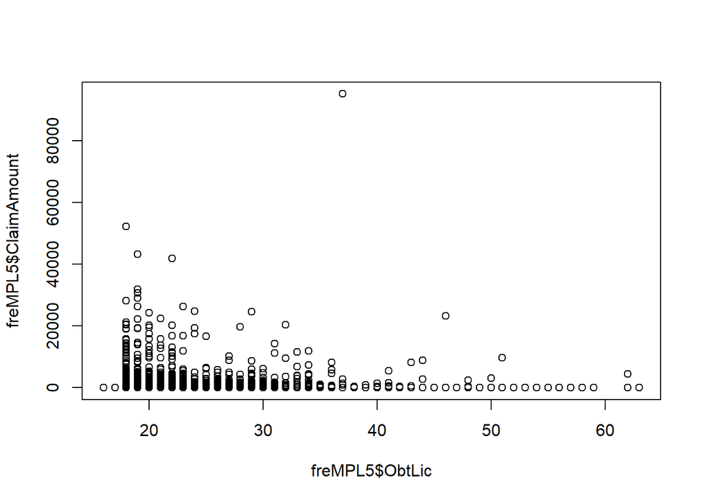

```r
plot(freMPL5$ClaimAmount ~ freMPL5$ObtLic)
```

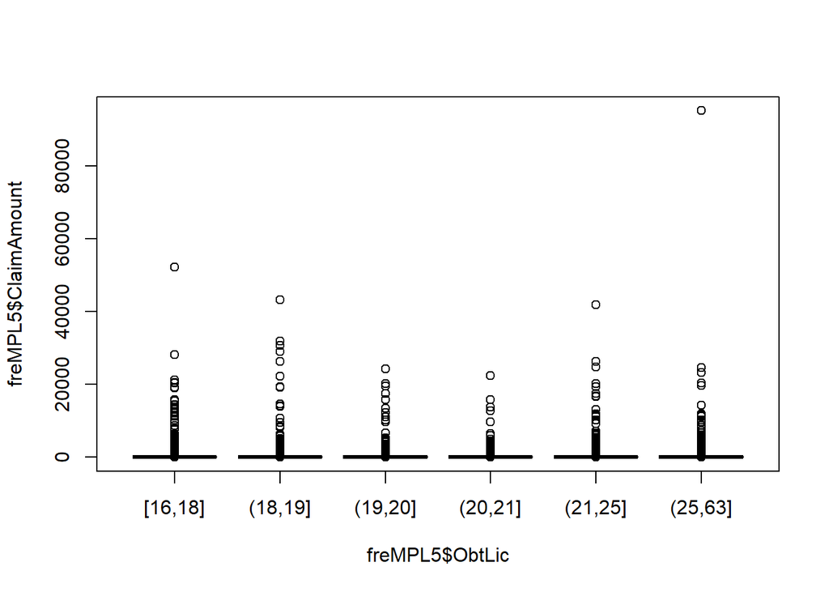

```r
freMPL5$ObtLic <- cut(freMPL5$ObtLic, quantile(freMPL5$ObtLic, probs = seq(0,1,1/6)), include.lowest = TRUE)
boxplot(freMPL5$ClaimAmount ~ freMPL5$ObtLic)
```

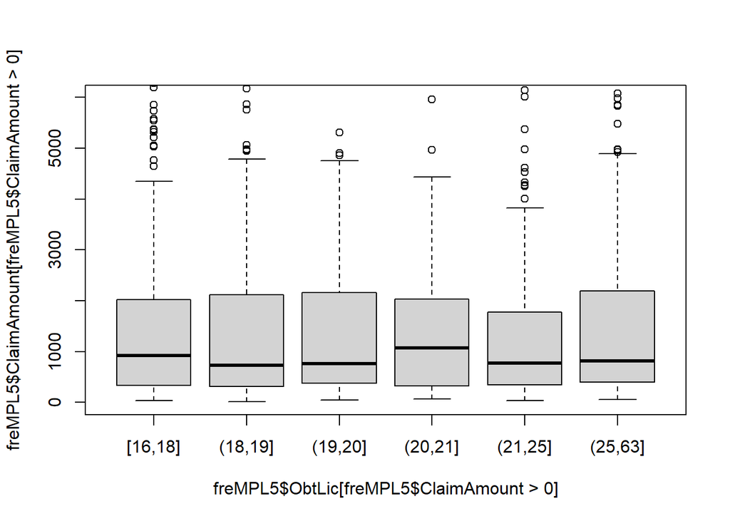

```r
boxplot(freMPL5$ClaimAmount[freMPL5$ClaimAmount>0] ~ freMPL5$ObtLic[freMPL5$ClaimAmount>0], ylim=c(0,6000))
```

Il n’y a pas de claire tendance mais cette covariable pourrait permettre d’affiner le modèle.

# Covariables liées au temps et à l’exposition

### Exposition

```r
summary(freMPL5$Exposure)
```

```
##    Min. 1st Qu.  Median    Mean 3rd Qu.    Max.
##  0.0010  0.1660  0.3990  0.4212  0.6610  1.0000
```

```r
cor.test(freMPL5$ClaimAmount, freMPL5$Exposure)
```

```
##
##  Pearson's product-moment correlation
##
## data:  freMPL5$ClaimAmount and freMPL5$Exposure
## t = 10.365, df = 25720, p-value < 2.2e-16
## alternative hypothesis: true correlation is not equal to 0
## 95 percent confidence interval:
##  0.05231644 0.07665637
## sample estimates:
##      cor
## 0.064496
```

```r
cor.test(as.numeric(freMPL5$ClaimInd), freMPL5$Exposure)
```

```
##
##  Pearson's product-moment correlation
##
## data:  as.numeric(freMPL5$ClaimInd) and freMPL5$Exposure
## t = 33.721, df = 25720, p-value < 2.2e-16
## alternative hypothesis: true correlation is not equal to 0
## 95 percent confidence interval:
##  0.1940327 0.2174396
## sample estimates:
##       cor
## 0.2057656
```

Il y a une claire corrélation et le facteur est très fort pour ClaimInd

##### Etude par rapport à la sinistralité

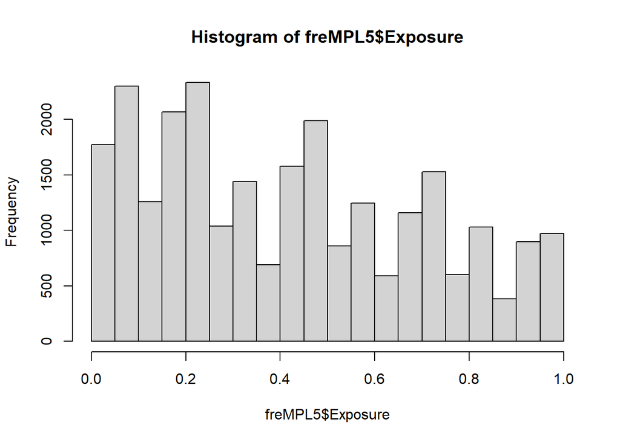

```r
hist(freMPL5$Exposure)
```

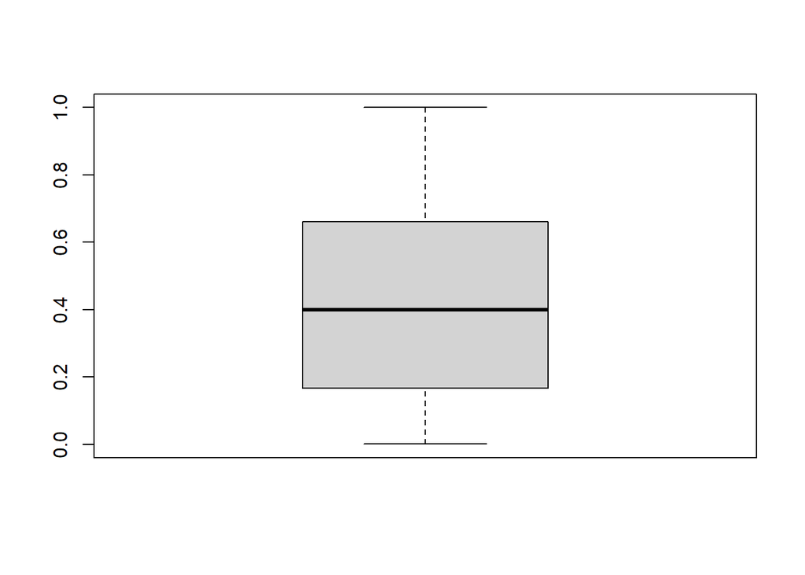

```r
boxplot(freMPL5$Exposure)
```

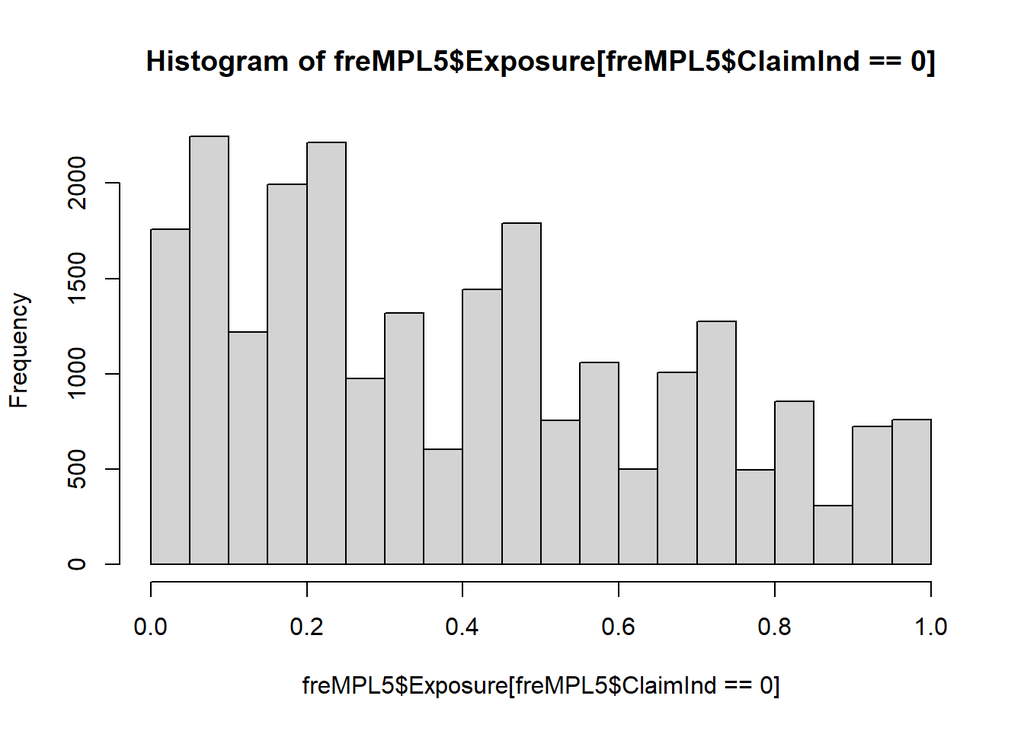

```r
hist(freMPL5$Exposure[freMPL5$ClaimInd == 0])
```

```r
summary(freMPL5$Exposure[freMPL5$ClaimInd == 0])
```

```
##    Min. 1st Qu.  Median    Mean 3rd Qu.    Max.
##  0.0010  0.1660  0.3470  0.4024  0.6110  1.0000
```

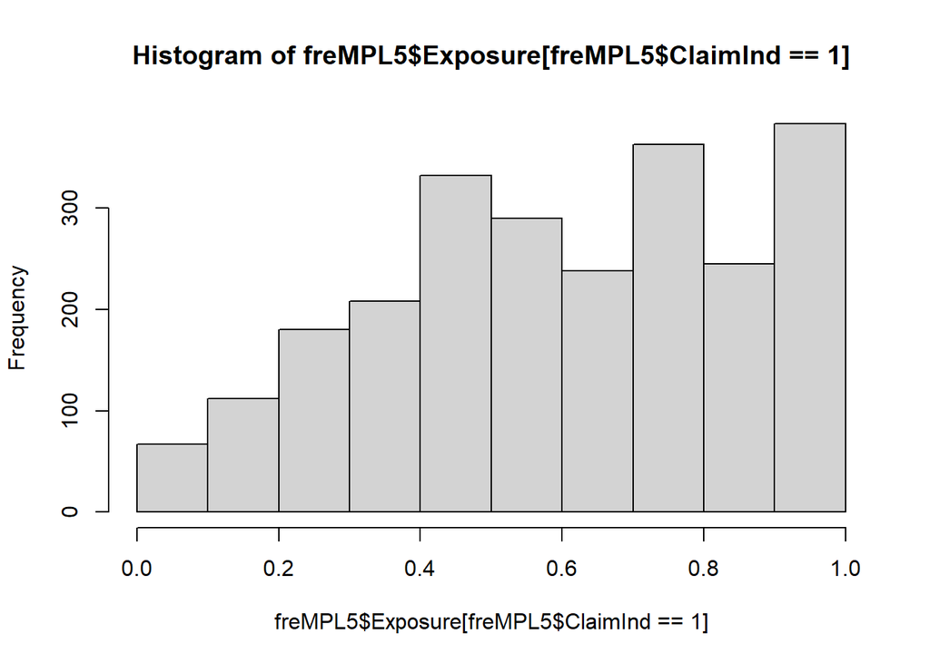

```r
hist(freMPL5$Exposure[freMPL5$ClaimInd == 1])
```

```r
summary(freMPL5$Exposure[freMPL5$ClaimInd == 1])
```

```
##    Min. 1st Qu.  Median    Mean 3rd Qu.    Max.
##  0.0020  0.4160  0.6110  0.6026  0.8190  1.0000
```

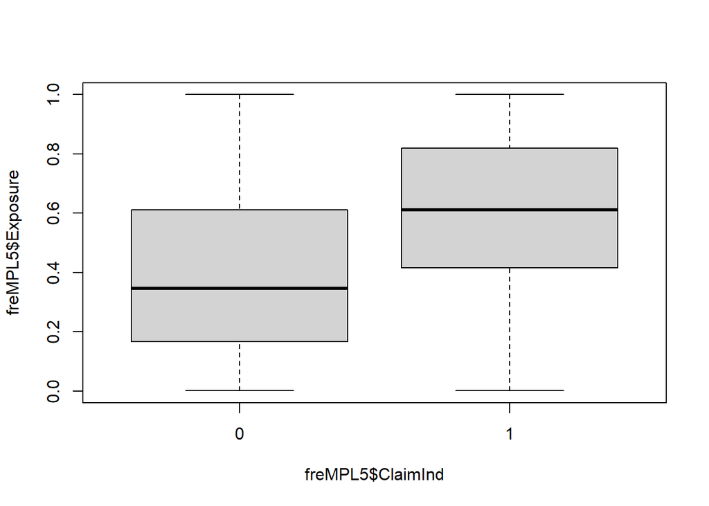

```r
boxplot(freMPL5$Exposure ~ freMPL5$ClaimInd)
```

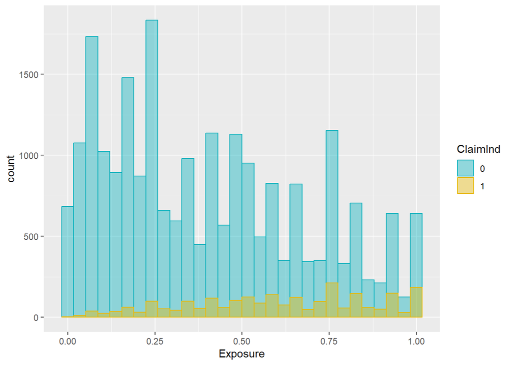

```r
ggplot(freMPL5, aes(x = Exposure)) +
  geom_histogram(aes(color = ClaimInd, fill = ClaimInd),
                position = "identity", bins = 30, alpha = 0.4) +
  scale_color_manual(values = c("#00AFBB", "#E7B800")) +
  scale_fill_manual(values = c("#00AFBB", "#E7B800"))
```

Les résultats semblent très intuitifs puisque plus on prend un intervalle de temps grand et plus l’assuré a de risque d’avoir un accident.

##### Etude par rapport au coût

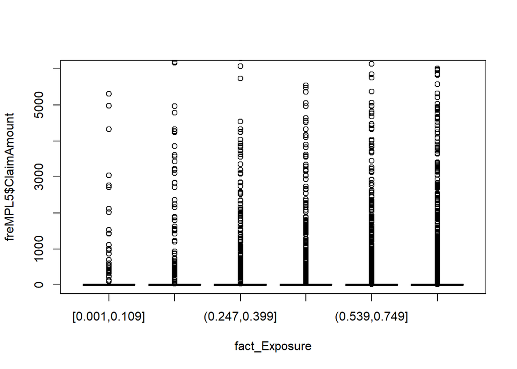

```r
fact_Exposure <- cut(freMPL5$Exposure, quantile(freMPL5$Exposure, probs = seq(0,1,1/6)), include.lowest = TRUE)
boxplot(freMPL5$ClaimAmount ~ fact_Exposure, ylim=c(0,6000))
```

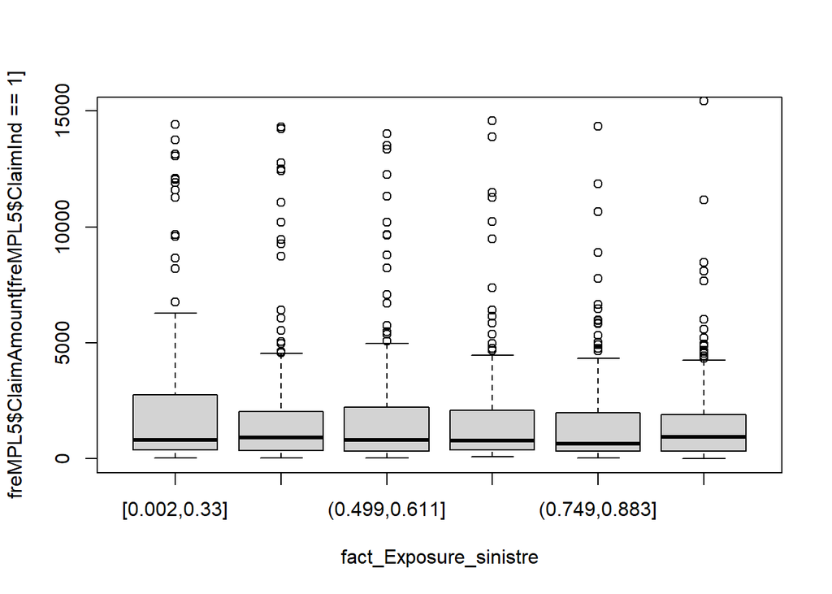

```r
fact_Exposure_sinistre <- cut(freMPL5$Exposure[freMPL5$ClaimInd == 1], quantile(freMPL5$Exposure[freMPL5$ClaimInd == 1], probs = seq(0,1,1/6)), include.lowest = TRUE)
boxplot(freMPL5$ClaimAmount[freMPL5$ClaimInd == 1] ~ fact_Exposure_sinistre, ylim=c(0,15000))
```

Sachant qu’on a eu un sinistre, on a alors que l’exposition n’est pas réellement impactant sur le coût des sinistres.

Nous étudierons cela plus en profondeur dans l’étude d’une éventuelle indépendance fréquence - coût moyen.

### Date de début

### Date de fin

# Covariables liées à l’état civil

### Genre

### Statut marital

### CSP

Cette catégorie devra être regroupée car elle contient trop de modalités de facteur.

```r
summary(freMPL5$SocioCateg)
```

```
##  CSP1 CSP17  CSP2 CSP20 CSP21 CSP22 CSP26  CSP3 CSP30 CSP37 CSP38 CSP40 CSP41
##   956     2    75    93   169   127   157    29     1   213     2    74     2
## CSP42 CSP44 CSP45 CSP46 CSP47 CSP48 CSP49 CSP50 CSP51 CSP55 CSP56 CSP57 CSP59
##   650     1     2   643    44   489    77 12236     6  3210     2     9     2
##  CSP6 CSP60 CSP61 CSP63 CSP65 CSP66  CSP7
##   171  5601     1     1    14   659     4
```

On peut considérer que, si une catégorie est représentée par moins de 300 personnes (sur l’échantillon des plus de 25000 contrats), alors on pourra les enlever.

# Covariables liées au véhicule ou à l’emplacement

### Utilisation du véhicule

```r
summary(freMPL5$VehUsage)
```

```
##                Private Private+trip to office           Professional
##                   8490                  12026                   4251
##       Professional run
##                    955
```

La variable VehUsage de notre jeu de données a quatre modalités concernant l’utilisation des vehicules (Private+trip to office, Private, Professionanal, Professional run). L’usage le plus fréquent étant “Private+trip to office” et la modalité la moins utilisée est “Professional run”

##### Etude par rapport à la sinistralité

```r
table(freMPL5$VehUsage, freMPL5$ClaimInd)
```

```
##
##                              0     1
##   Private                 7818   672
##   Private+trip to office 10915  1111
##   Professional            3735   516
##   Professional run         836   119
```

```r
summary(freMPL5$VehUsage[freMPL5$ClaimInd == 0])
```

```
##                Private Private+trip to office           Professional
##                   7818                  10915                   3735
##       Professional run
##                    836
```

```r
summary(freMPL5$VehUsage[freMPL5$ClaimInd == 1])
```

```
##                Private Private+trip to office           Professional
##                    672                   1111                    516
##       Professional run
##                    119
```

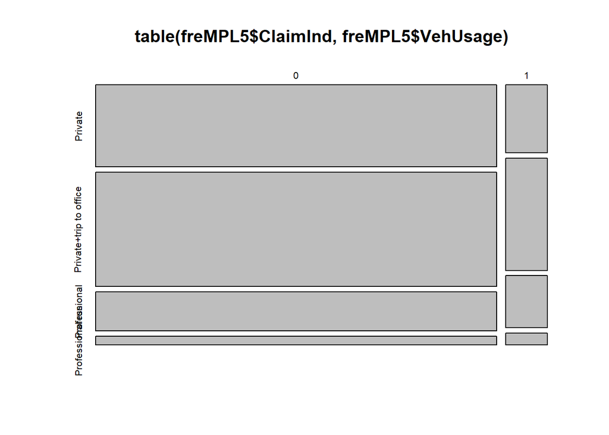

```r
mosaicplot(table(freMPL5$ClaimInd,freMPL5$VehUsage))
```

##### Etude par rapport au coût

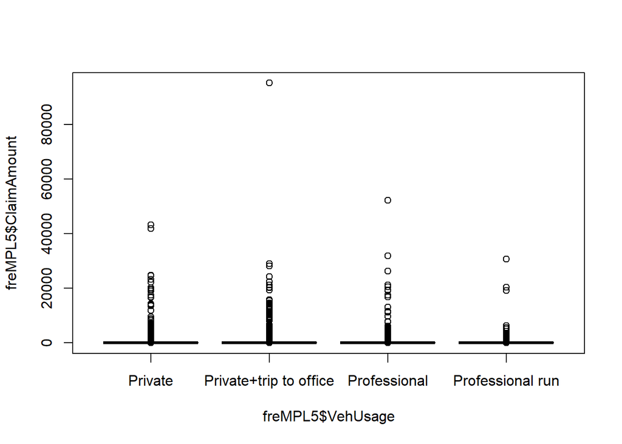

```r
plot(freMPL5$ClaimAmount ~ freMPL5$VehUsage)
```

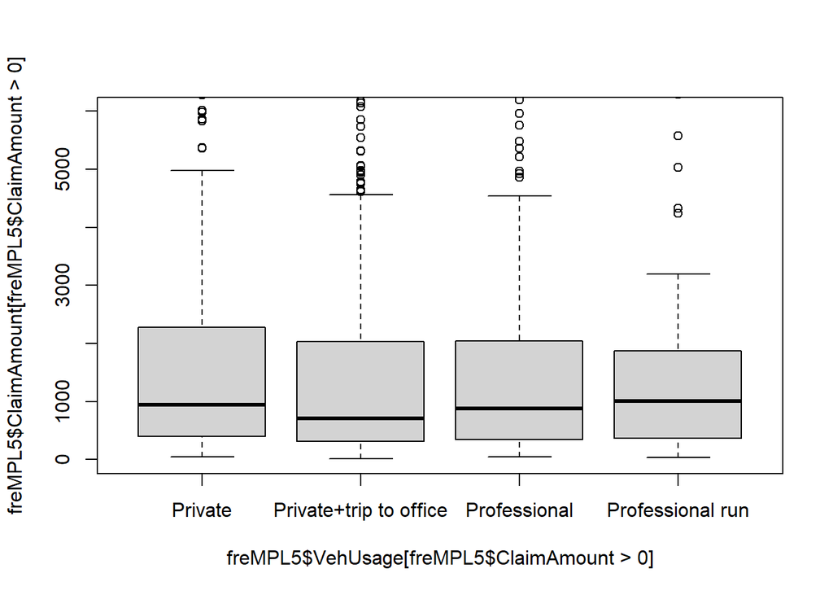

```r
boxplot(freMPL5$ClaimAmount[freMPL5$ClaimAmount>0] ~ freMPL5$VehUsage[freMPL5$ClaimAmount>0], ylim=c(0,6000))
```

### Limite kilométrique

```r
summary(freMPL5$HasKmLimit)
```

```
##     0     1
## 23789  1933
```

##### Etude par rapport à la sinistralit

```r
table(freMPL5$HasKmLimit, freMPL5$ClaimInd)
```

```
##
##         0     1
##   0 21505  2284
##   1  1799   134
```

```r
summary(freMPL5$HasKmLimit[freMPL5$ClaimInd == 0])
```

```
##     0     1
## 21505  1799
```

```r
summary(freMPL5$HasKmLimit[freMPL5$ClaimInd == 1])
```

```
##    0    1
## 2284  134
```

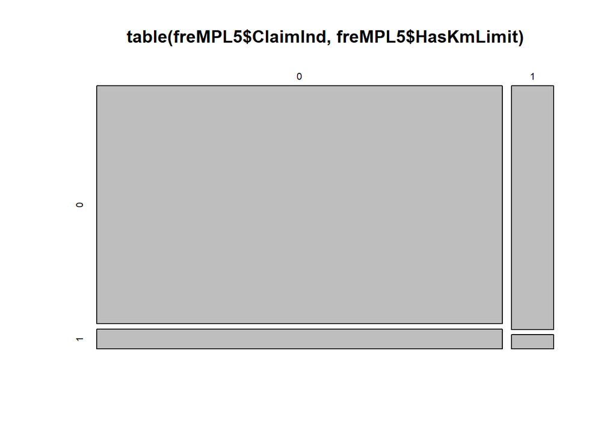

```r
mosaicplot(table(freMPL5$ClaimInd,freMPL5$HasKmLimit))
```

Que ce soit avec ou sans limite de km sur le contrat, une faible partie des individus auront tendances à avoir un sinistre.

##### Etude par rapport au coût

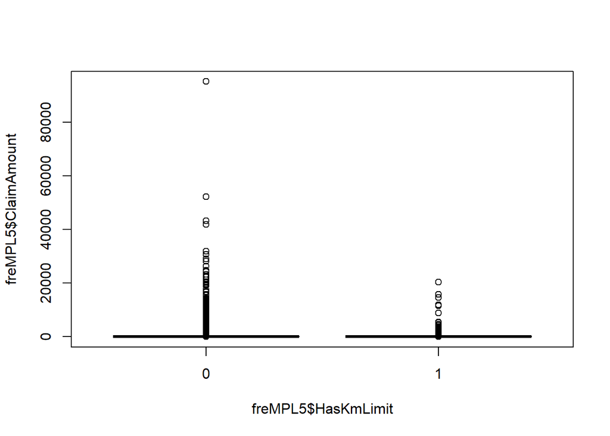

```r
boxplot(freMPL5$ClaimAmount ~ freMPL5$HasKmLimit)
```

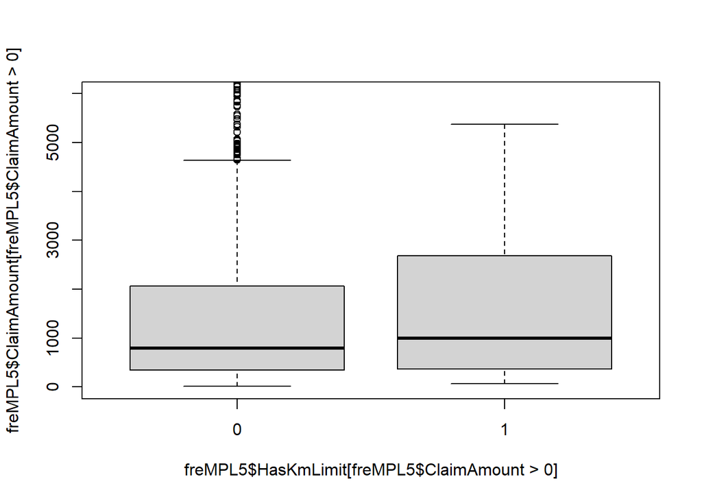

```r
boxplot(freMPL5$ClaimAmount[freMPL5$ClaimAmount>0] ~ freMPL5$HasKmLimit[freMPL5$ClaimAmount>0], ylim=c(0,6000))
```

Lègère tendance à la hausse du prix à payer pour les individus ayant pris un contrat avec une limite de km

### Zone de risque

Cette catégorie devra être regroupée (idem CSP)

```r
summary(freMPL5$RiskArea)
```

```
##    1    2    3    4    5    6    7    8    9   10   11   12   13
##   13  341  469  892 1523 3816 6034 1217 3788 4566 2981   57   25
```

Très peu d’individu sont classés dans les zones de risques de niveau 1, 12 et 13.

##### Etude par rapport à la sinistralité

```r
table(freMPL5$RiskArea,freMPL5$ClaimInd)
```

```
##
##         0    1
##   1    13    0
##   2   306   35
##   3   423   46
##   4   779  113
##   5  1381  142
##   6  3493  323
##   7  5531  503
##   8  1117  100
##   9  3432  356
##   10 4105  461
##   11 2649  332
##   12   52    5
##   13   23    2
```

```r
summary(freMPL5$RiskArea[freMPL5$ClaimInd == 0])
```

```
##    1    2    3    4    5    6    7    8    9   10   11   12   13
##   13  306  423  779 1381 3493 5531 1117 3432 4105 2649   52   23
```

```r
summary(freMPL5$RiskArea[freMPL5$ClaimInd == 1])
```

```
##   1   2   3   4   5   6   7   8   9  10  11  12  13
##   0  35  46 113 142 323 503 100 356 461 332   5   2
```

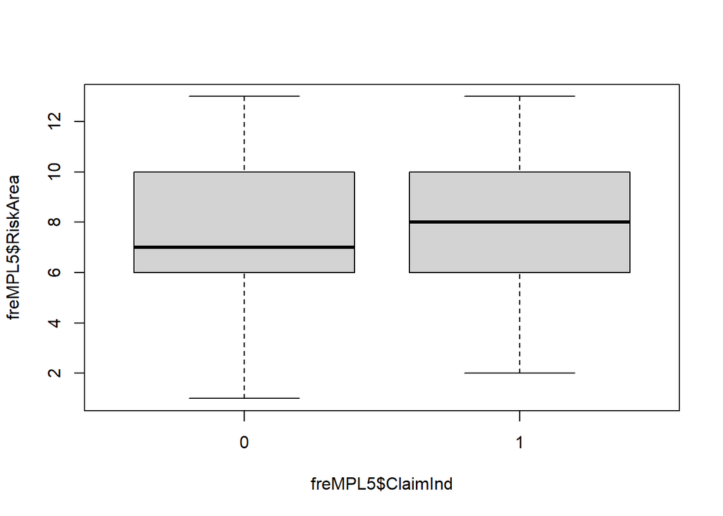

```r
boxplot(freMPL5$RiskArea ~ freMPL5$ClaimInd)
```

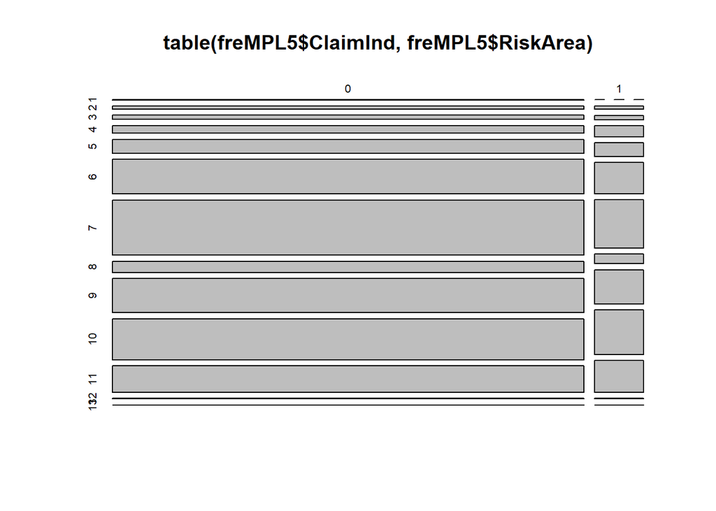

```r
mosaicplot(table(freMPL5$ClaimInd,freMPL5$RiskArea))
```

A chaque zone de risque, il y a largement davantage d’individus n’ayant pas déclaré de garanti que d’individu ayant déclaré une garanti.

##### Etude par rapport au coût

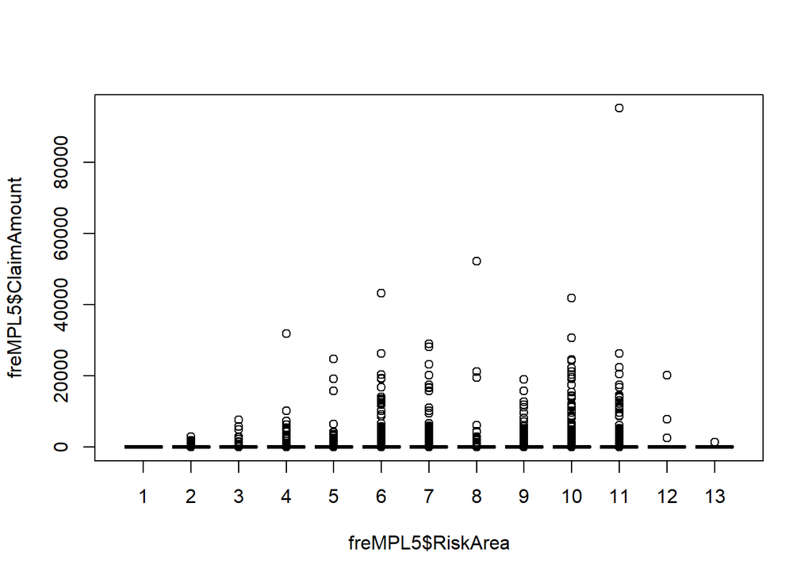

```r
plot(freMPL5$ClaimAmount ~ freMPL5$RiskArea)
```

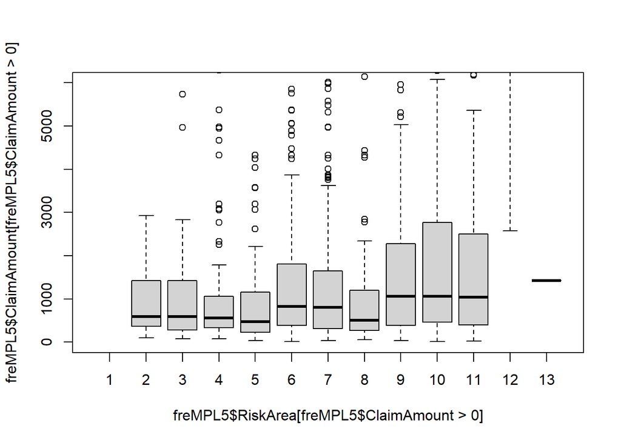

```r
boxplot(freMPL5$ClaimAmount[freMPL5$ClaimAmount>0] ~ freMPL5$RiskArea[freMPL5$ClaimAmount>0], ylim=c(0,6000))
```

Les individus ayant tendances à payer plus cher les sinistres se situent dans les zones de risques de niveau les plus élévées.

# Covariables liées aux sinitres durant les 4 années précédentes

```r
cor.test(freMPL5$ClaimNbResp+freMPL5$ClaimNbNonResp+freMPL5$ClaimNbParking+freMPL5$ClaimNbFireTheft+freMPL5$ClaimNbWindscreen+freMPL5$OutUseNb, as.numeric(freMPL5$ClaimInd))
```

```
##
##  Pearson's product-moment correlation
##
## data:  freMPL5$ClaimNbResp + freMPL5$ClaimNbNonResp + freMPL5$ClaimNbParking + freMPL5$ClaimNbFireTheft + freMPL5$ClaimNbWindscreen + freMPL5$OutUseNb and as.numeric(freMPL5$ClaimInd)
## t = 9.8872, df = 25720, p-value < 2.2e-16
## alternative hypothesis: true correlation is not equal to 0
## 95 percent confidence interval:
##  0.04935002 0.07369908
## sample estimates:
##       cor
## 0.0615337
```

```r
cor.test(freMPL5$ClaimNbResp+freMPL5$ClaimNbNonResp+freMPL5$ClaimNbParking+freMPL5$ClaimNbFireTheft+freMPL5$ClaimNbWindscreen+freMPL5$OutUseNb, as.numeric(freMPL5$ClaimInd), method = "kendall")
```

```
##
##  Kendall's rank correlation tau
##
## data:  freMPL5$ClaimNbResp + freMPL5$ClaimNbNonResp + freMPL5$ClaimNbParking + freMPL5$ClaimNbFireTheft + freMPL5$ClaimNbWindscreen + freMPL5$OutUseNb and as.numeric(freMPL5$ClaimInd)
## z = 10.682, p-value < 2.2e-16
## alternative hypothesis: true tau is not equal to 0
## sample estimates:
##        tau
## 0.06038155
```

```r
cor.test(freMPL5$ClaimNbResp+freMPL5$ClaimNbNonResp+freMPL5$ClaimNbParking+freMPL5$ClaimNbFireTheft+freMPL5$ClaimNbWindscreen+freMPL5$OutUseNb, as.numeric(freMPL5$ClaimAmount))
```

```
##
##  Pearson's product-moment correlation
##
## data:  freMPL5$ClaimNbResp + freMPL5$ClaimNbNonResp + freMPL5$ClaimNbParking + freMPL5$ClaimNbFireTheft + freMPL5$ClaimNbWindscreen + freMPL5$OutUseNb and as.numeric(freMPL5$ClaimAmount)
## t = 8.0217, df = 25720, p-value = 1.087e-15
## alternative hypothesis: true correlation is not equal to 0
## 95 percent confidence interval:
##  0.03775843 0.06213903
## sample estimates:
##        cor
## 0.04995617
```

```r
cor.test(freMPL5$ClaimNbResp+freMPL5$ClaimNbNonResp+freMPL5$ClaimNbParking+freMPL5$ClaimNbFireTheft+freMPL5$ClaimNbWindscreen+freMPL5$OutUseNb, as.numeric(freMPL5$ClaimAmount), method = "kendall")
```

```
##
##  Kendall's rank correlation tau
##
## data:  freMPL5$ClaimNbResp + freMPL5$ClaimNbNonResp + freMPL5$ClaimNbParking + freMPL5$ClaimNbFireTheft + freMPL5$ClaimNbWindscreen + freMPL5$OutUseNb and as.numeric(freMPL5$ClaimAmount)
## z = 10.776, p-value < 2.2e-16
## alternative hypothesis: true tau is not equal to 0
## sample estimates:
##        tau
## 0.05949107
```

En utilisant le test de Pearson et le test de Kendall, on obtient que la somme des sinitres possibles est corrélée avec l’indicateur ClaimInd mais aussi avec la variable ClaimAmount. Nous allons donc les étudier indépendament pour trouver l’impact de ces covariables sur les variables à expliquer.

### Accident responsable

```r
summary(freMPL5$ClaimNbResp)
```

```
##    Min. 1st Qu.  Median    Mean 3rd Qu.    Max.
##  0.0000  0.0000  0.0000  0.2658  0.0000  4.0000
```

```r
quantile(freMPL5$ClaimNbResp, seq(0,1,1/10))
```

```
##   0%  10%  20%  30%  40%  50%  60%  70%  80%  90% 100%
##    0    0    0    0    0    0    0    0    1    1    4
```

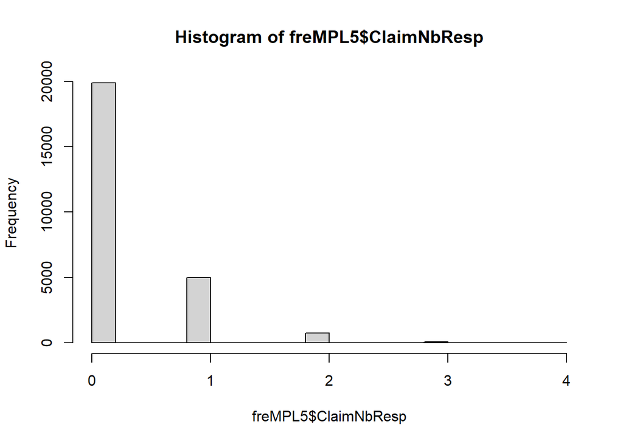

```r
hist(freMPL5$ClaimNbResp)
```

L’évènement d’avoir au moins un accident responsable est assez rare (environ 20%).

##### Etude par rapport à la sinistralité

```r
cor.test(freMPL5$ClaimNbResp, as.numeric(freMPL5$ClaimInd))
```

```
##
##  Pearson's product-moment correlation
##
## data:  freMPL5$ClaimNbResp and as.numeric(freMPL5$ClaimInd)
## t = 5.853, df = 25720, p-value = 4.888e-09
## alternative hypothesis: true correlation is not equal to 0
## 95 percent confidence interval:
##  0.02426126 0.04867035
## sample estimates:
##        cor
## 0.03647125
```

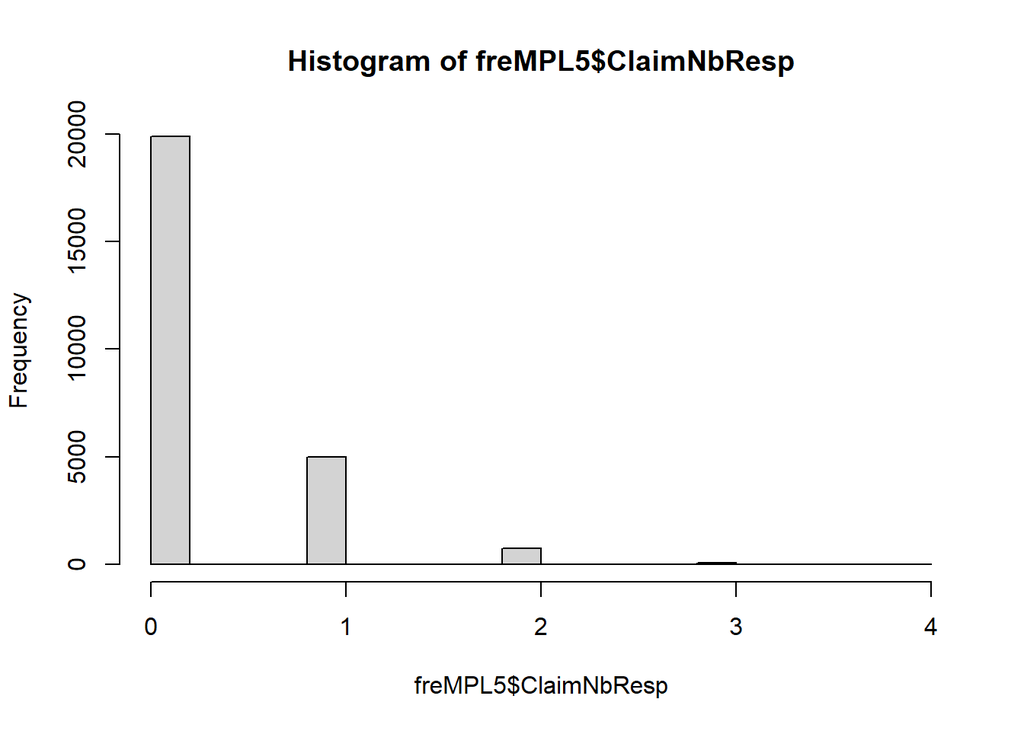

```r
hist(freMPL5$ClaimNbResp)
```

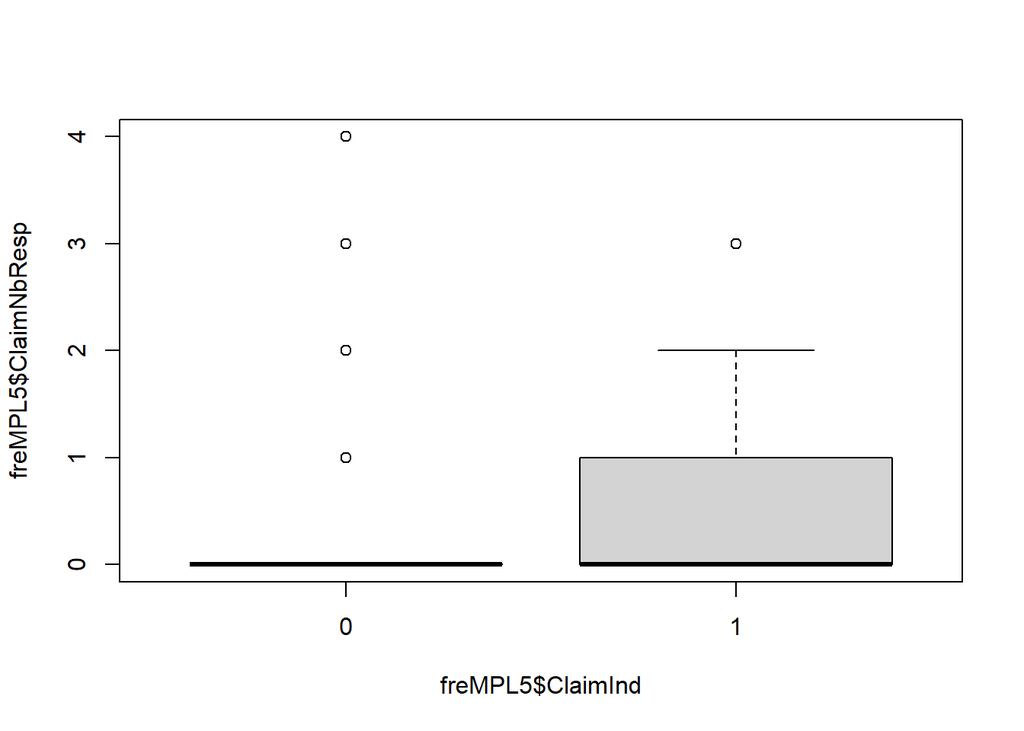

```r
boxplot(freMPL5$ClaimNbResp ~ freMPL5$ClaimInd)
```

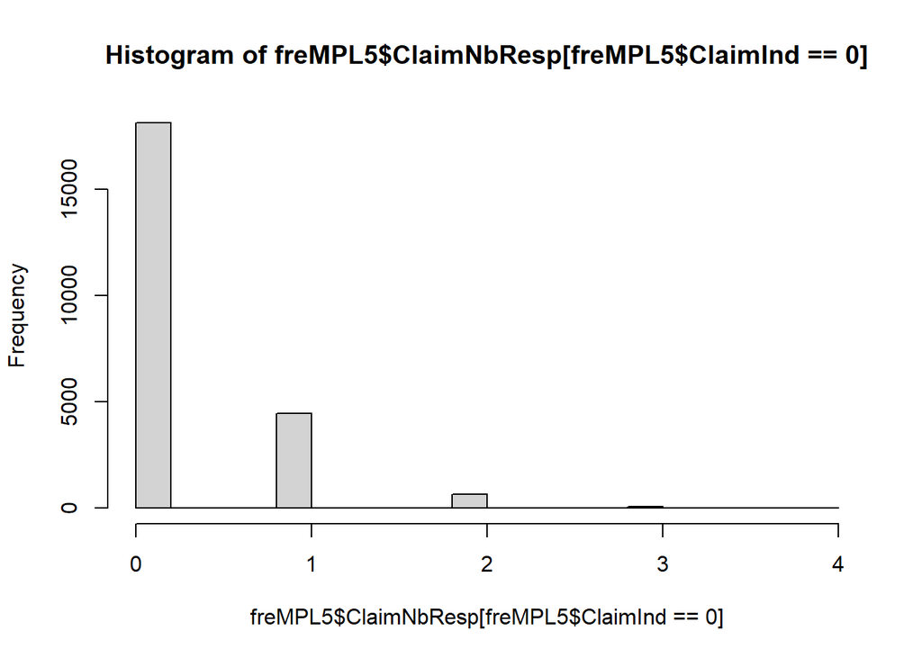

```r
hist(freMPL5$ClaimNbResp[freMPL5$ClaimInd == 0])
```

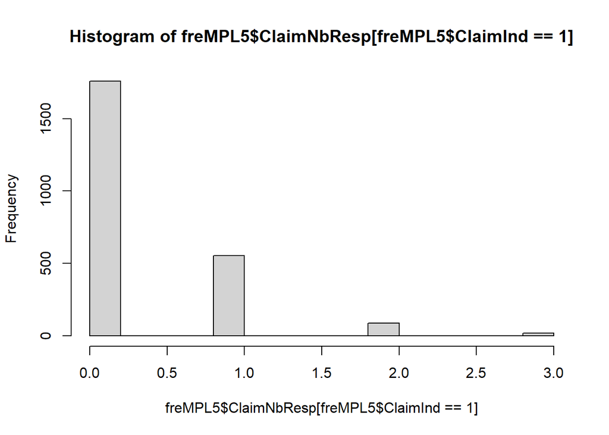

```r
hist(freMPL5$ClaimNbResp[freMPL5$ClaimInd == 1])
```

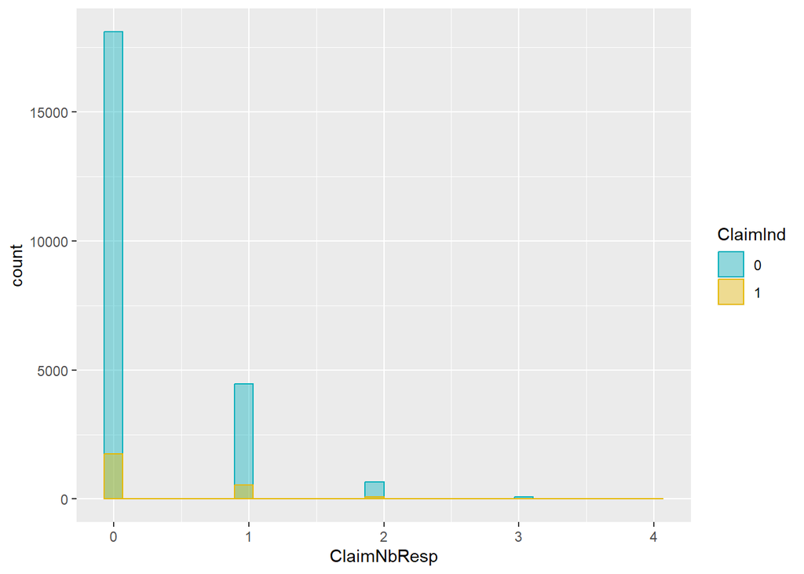

```r
ggplot(freMPL5, aes(x = ClaimNbResp)) +
  geom_histogram(aes(color = ClaimInd, fill = ClaimInd),
                position = "identity", bins = 30, alpha = 0.4) +
  scale_color_manual(values = c("#00AFBB", "#E7B800")) +
  scale_fill_manual(values = c("#00AFBB", "#E7B800"))
```

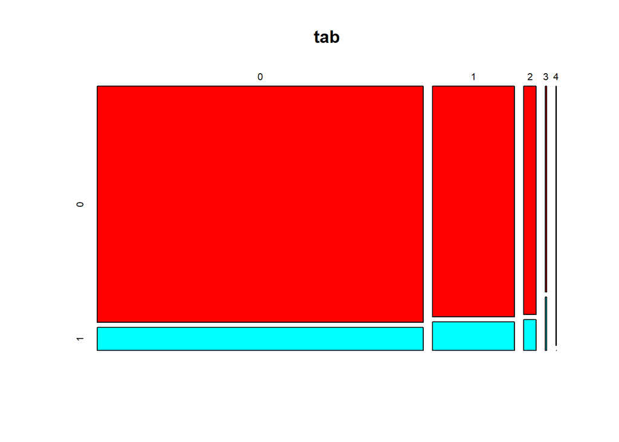

```r
tab <- table(freMPL5$ClaimNbResp, freMPL5$ClaimInd)
cols <- rainbow(nlevels(freMPL5$ClaimInd))
plot(tab,col = cols)
```

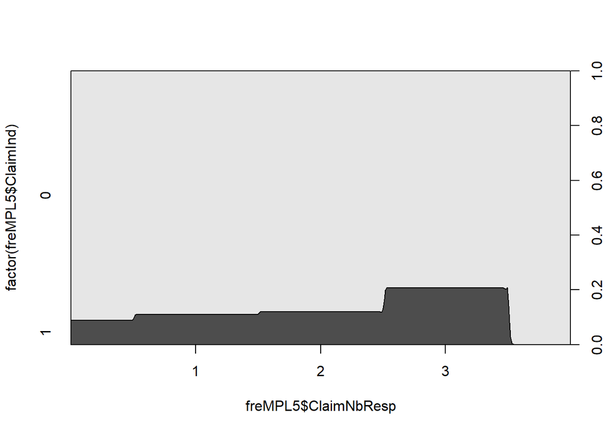

```r
cdplot(x = freMPL5$ClaimNbResp, y = factor(freMPL5$ClaimInd))
```

Il y a ici aussi une petite corrélation. Avec les graphiques, on remarque qu’il y a plus d’indicateurs de réclamation positifs lorsque les accidents sont responsables.

##### Etude par rapport au coût

```r
cor.test(freMPL5$ClaimNbResp, freMPL5$ClaimAmount)
```

```
##
##  Pearson's product-moment correlation
##
## data:  freMPL5$ClaimNbResp and freMPL5$ClaimAmount
## t = 9.056, df = 25720, p-value < 2.2e-16
## alternative hypothesis: true correlation is not equal to 0
## 95 percent confidence interval:
##  0.04418749 0.06855140
## sample estimates:
##        cor
## 0.05637784
```

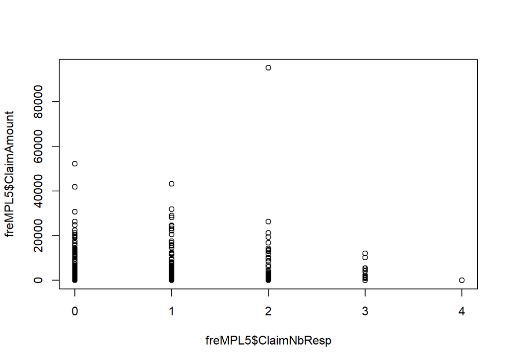

```r
plot(freMPL5$ClaimAmount ~ freMPL5$ClaimNbResp)
```

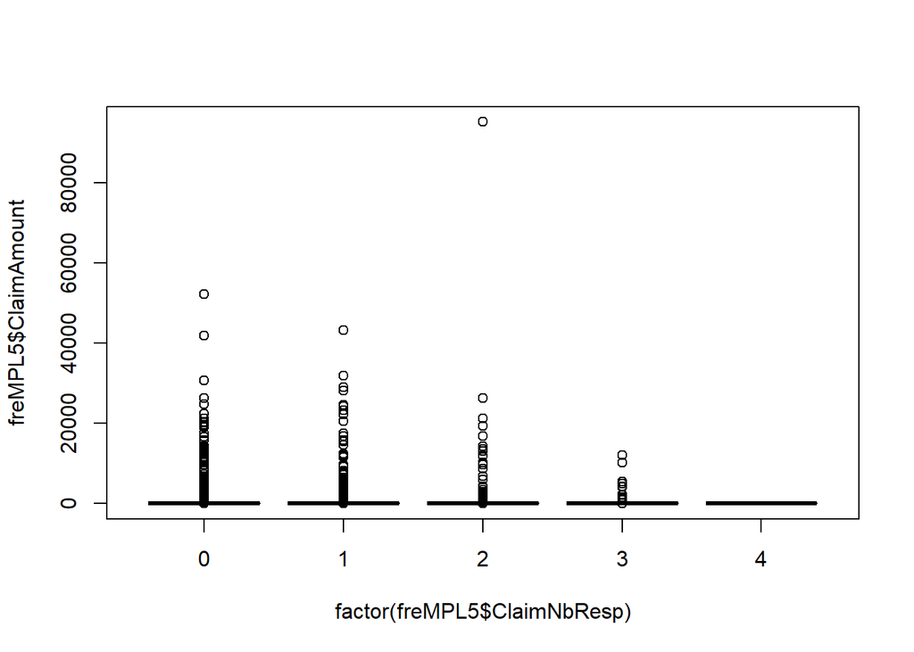

```r
boxplot(freMPL5$ClaimAmount ~ factor(freMPL5$ClaimNbResp))
```

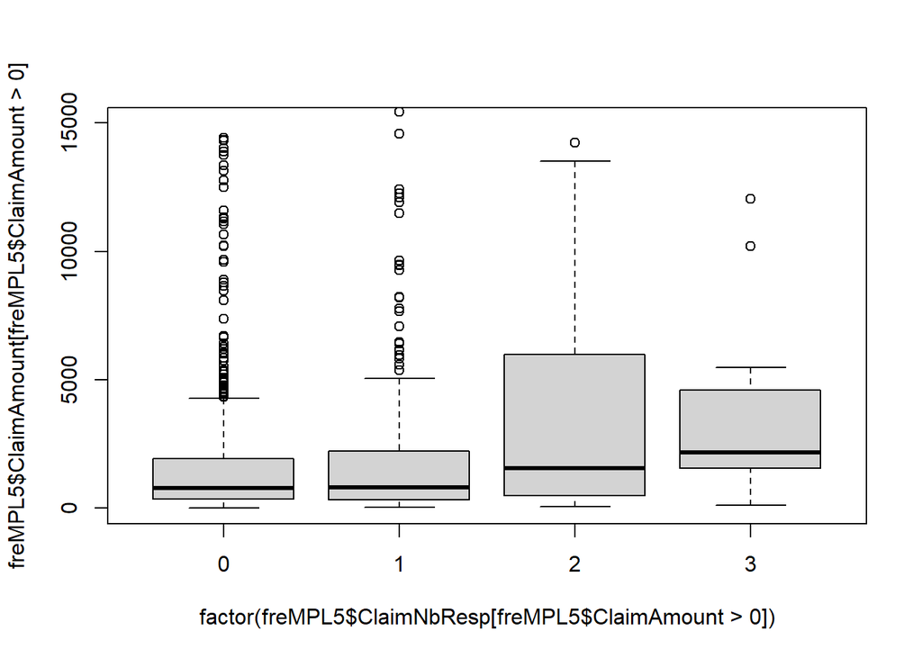

```r
boxplot(freMPL5$ClaimAmount[freMPL5$ClaimAmount>0] ~ factor(freMPL5$ClaimNbResp[freMPL5$ClaimAmount>0]), ylim=c(0,15000))
```

La corrélation est surtout observable entre cette variable et la variable de coût moyen.

### Accident non-responsable

```r
summary(freMPL5$ClaimNbNonResp)
```

```
##    Min. 1st Qu.  Median    Mean 3rd Qu.    Max.
##   0.000   0.000   0.000   0.321   1.000   7.000
```

```r
quantile(freMPL5$ClaimNbNonResp, seq(0,1,1/10))
```

```
##   0%  10%  20%  30%  40%  50%  60%  70%  80%  90% 100%
##    0    0    0    0    0    0    0    0    1    1    7
```

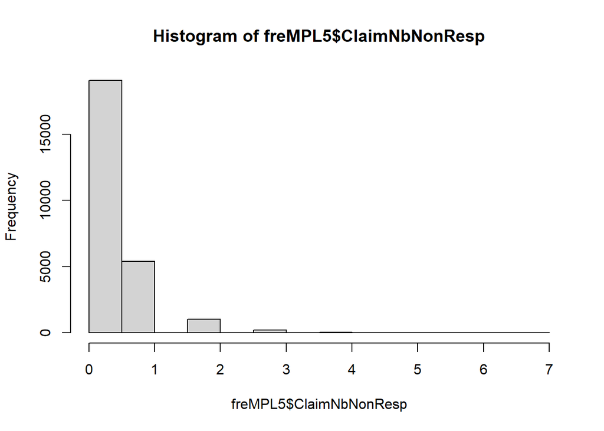

```r
hist(freMPL5$ClaimNbNonResp)
```

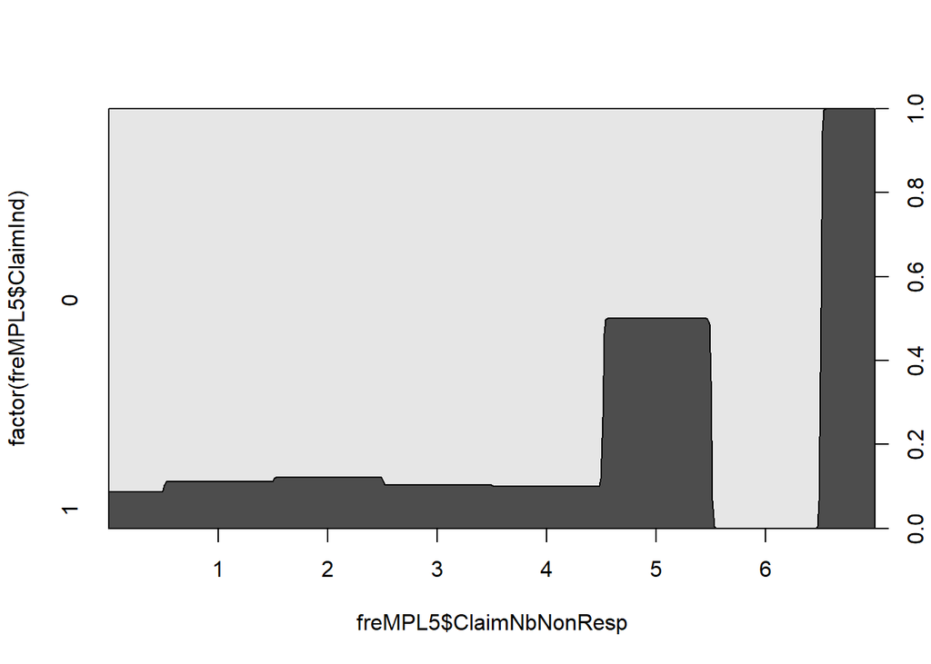

```r
cdplot(x = freMPL5$ClaimNbNonResp, y = factor(freMPL5$ClaimInd))
```

L’évènement d’avoir au moins un accident non responsable est assez rare (environ 20%).

##### Etude par rapport à la sinistralité

```r
cor.test(freMPL5$ClaimNbNonResp, as.numeric(freMPL5$ClaimInd))
```

```
##
##  Pearson's product-moment correlation
##
## data:  freMPL5$ClaimNbNonResp and as.numeric(freMPL5$ClaimInd)
## t = 6.0994, df = 25720, p-value = 1.08e-09
## alternative hypothesis: true correlation is not equal to 0
## 95 percent confidence interval:
##  0.02579589 0.05020219
## sample estimates:
##        cor
## 0.03800471
```

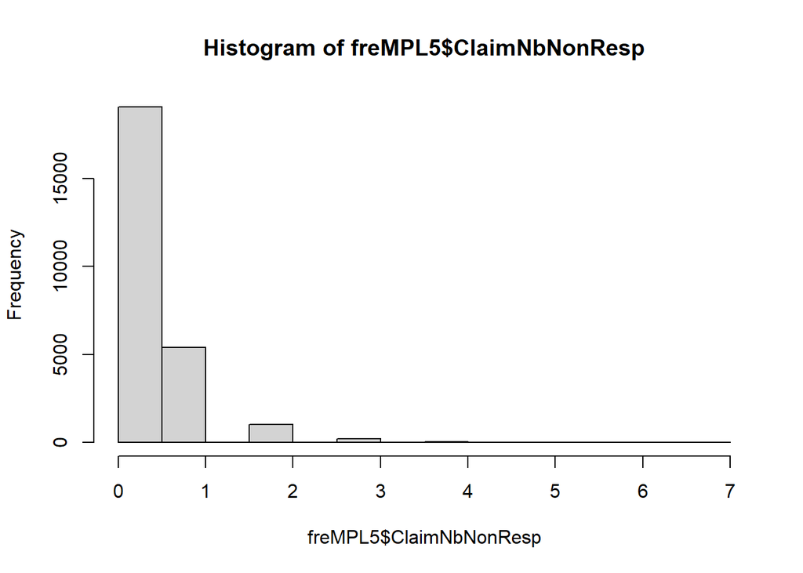

```r
hist(freMPL5$ClaimNbNonResp)
```

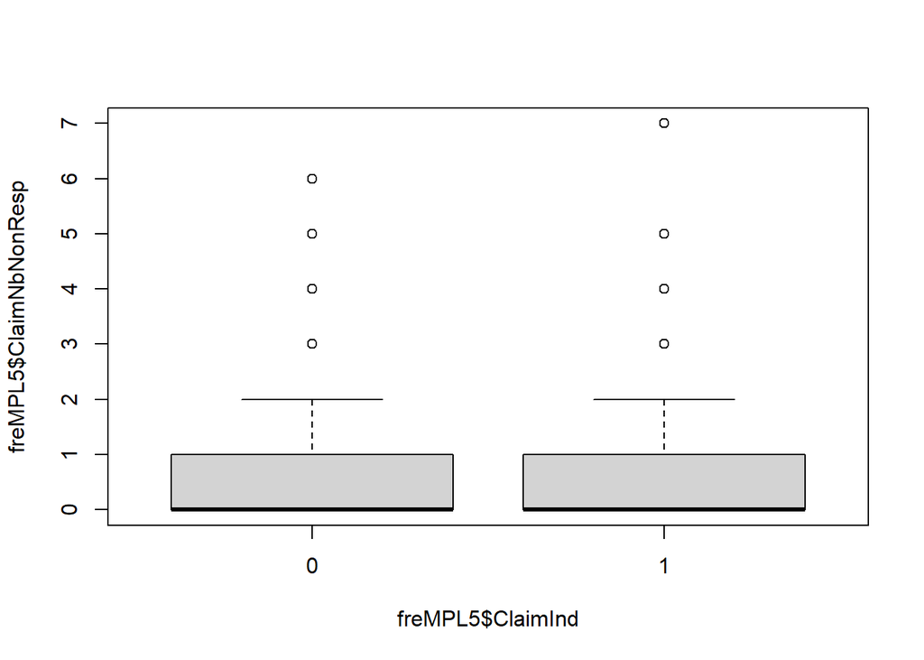

```r
boxplot(freMPL5$ClaimNbNonResp ~ freMPL5$ClaimInd)
```

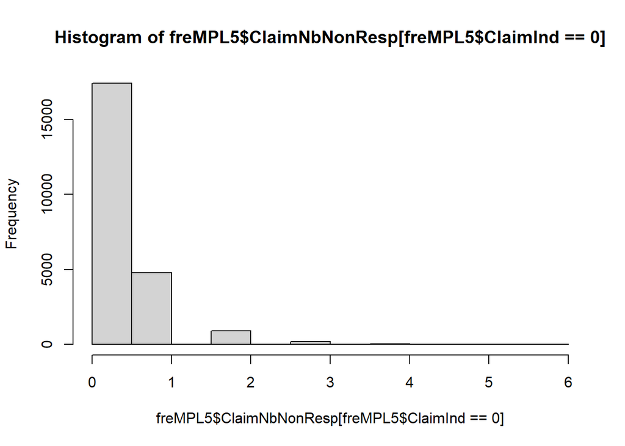

```r
hist(freMPL5$ClaimNbNonResp[freMPL5$ClaimInd == 0])
```

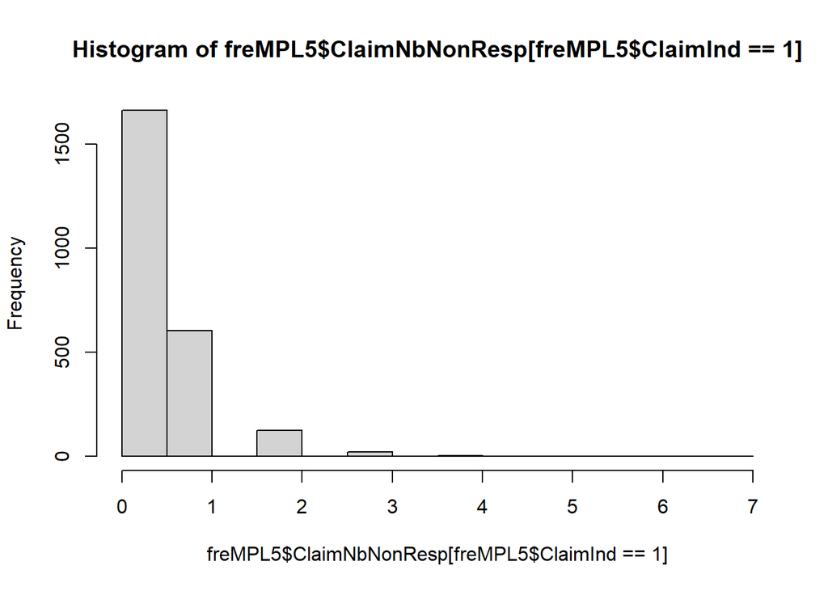

```r
hist(freMPL5$ClaimNbNonResp[freMPL5$ClaimInd == 1])
```

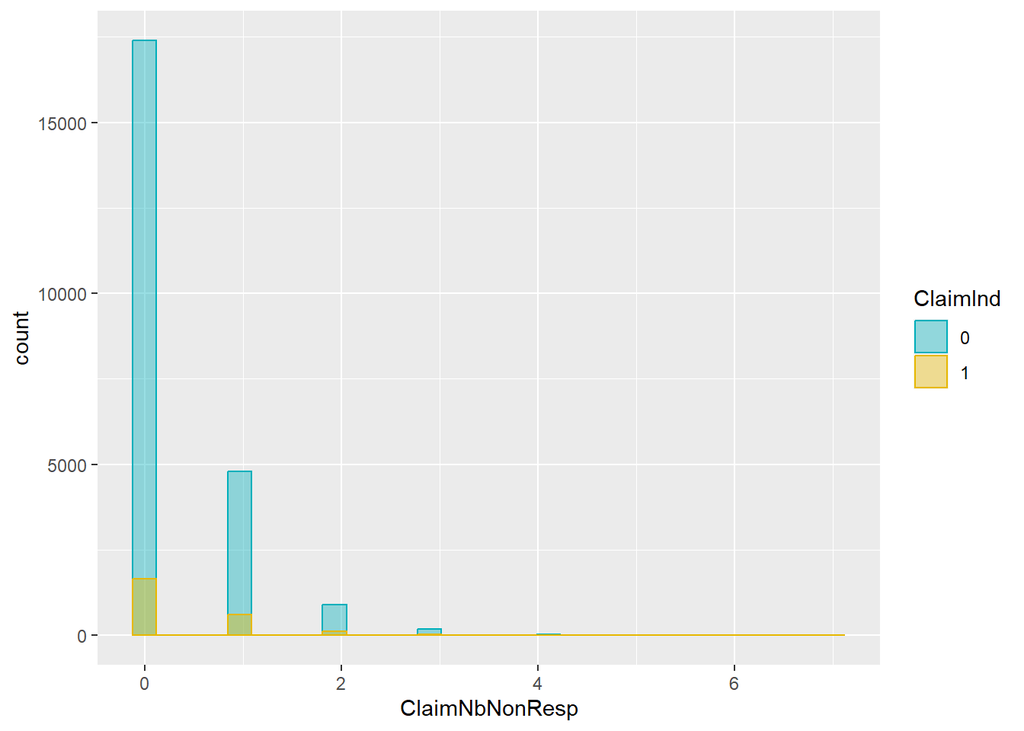

```r
ggplot(freMPL5, aes(x = ClaimNbNonResp)) +
  geom_histogram(aes(color = ClaimInd, fill = ClaimInd),
                position = "identity", bins = 30, alpha = 0.4) +
  scale_color_manual(values = c("#00AFBB", "#E7B800")) +
  scale_fill_manual(values = c("#00AFBB", "#E7B800"))
```

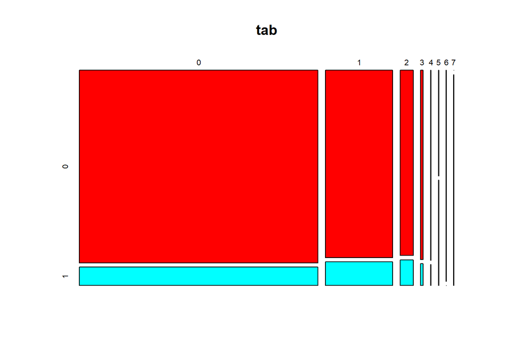

```r
tab <- table(freMPL5$ClaimNbNonResp, freMPL5$ClaimInd)
cols <- rainbow(nlevels(freMPL5$ClaimInd))
plot(tab,col = cols)
```

Il y a ici aussi une petite corrélation. Avec les graphiques, on remarque qu’il y a plus d’indicateurs de réclamation positifs lorsqu’il y a des accidents non responsables.

##### Etude par rapport au coût

```r
cor.test(freMPL5$ClaimNbNonResp, freMPL5$ClaimAmount)
```

```
##
##  Pearson's product-moment correlation
##
## data:  freMPL5$ClaimNbNonResp and freMPL5$ClaimAmount
## t = 7.3174, df = 25720, p-value = 2.603e-13
## alternative hypothesis: true correlation is not equal to 0
## 95 percent confidence interval:
##  0.03337713 0.05776794
## sample estimates:
##        cor
## 0.04557933
```

```r
summary(as.factor(freMPL5$ClaimNbNonResp))
```

```
##     0     1     2     3     4     5     6     7
## 19052  5392  1027   204    40     4     2     1
```

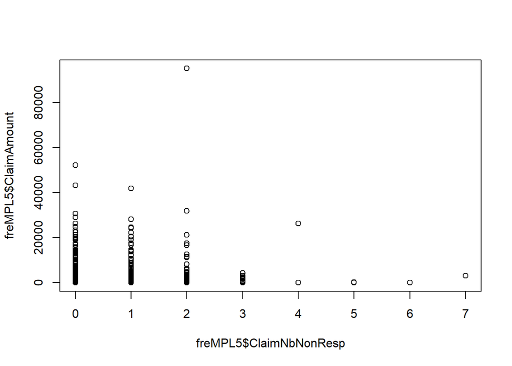

```r
plot(freMPL5$ClaimAmount ~ freMPL5$ClaimNbNonResp)
```

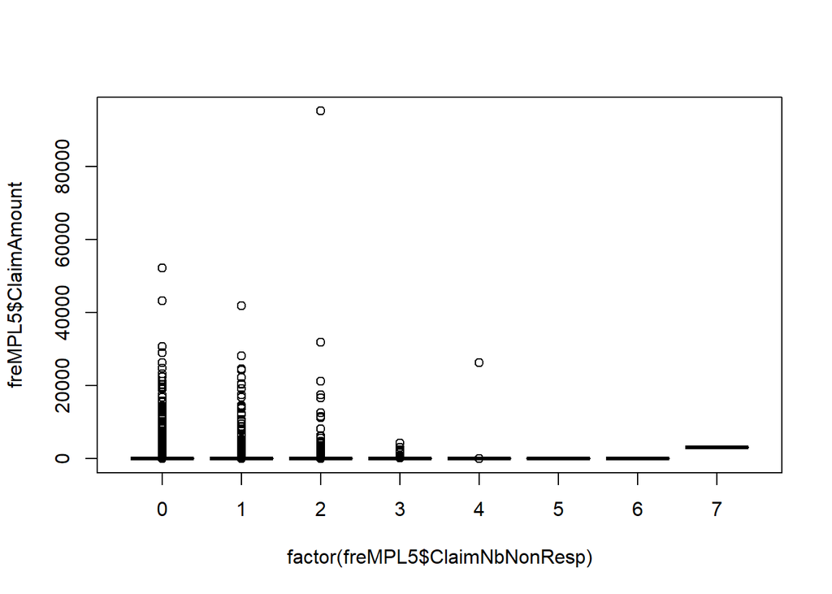

```r
boxplot(freMPL5$ClaimAmount ~ factor(freMPL5$ClaimNbNonResp))
```

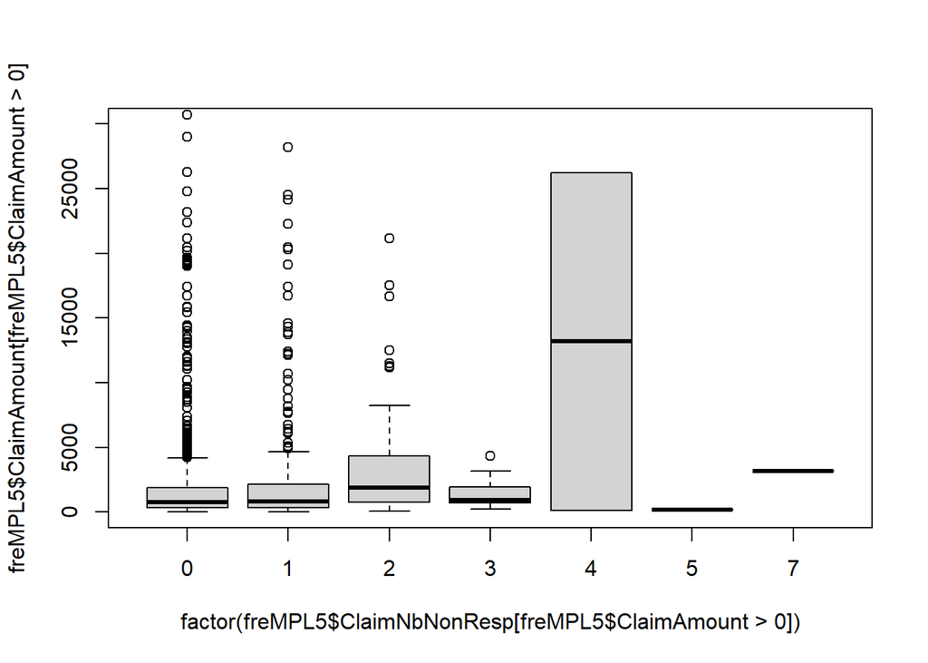

```r
boxplot(freMPL5$ClaimAmount[freMPL5$ClaimAmount>0] ~ factor(freMPL5$ClaimNbNonResp[freMPL5$ClaimAmount>0]), ylim=c(0,30000))
```

La corrélation est légerement observable entre cette variable et le coût moyen.

### Parking

```r
summary(freMPL5$ClaimNbParking)
```

```
##    Min. 1st Qu.  Median    Mean 3rd Qu.    Max.
## 0.00000 0.00000 0.00000 0.08292 0.00000 4.00000
```

```r
quantile(freMPL5$ClaimNbParking, seq(0,1,1/20))
```

```
##   0%   5%  10%  15%  20%  25%  30%  35%  40%  45%  50%  55%  60%  65%  70%  75%
##    0    0    0    0    0    0    0    0    0    0    0    0    0    0    0    0
##  80%  85%  90%  95% 100%
##    0    0    0    1    4
```

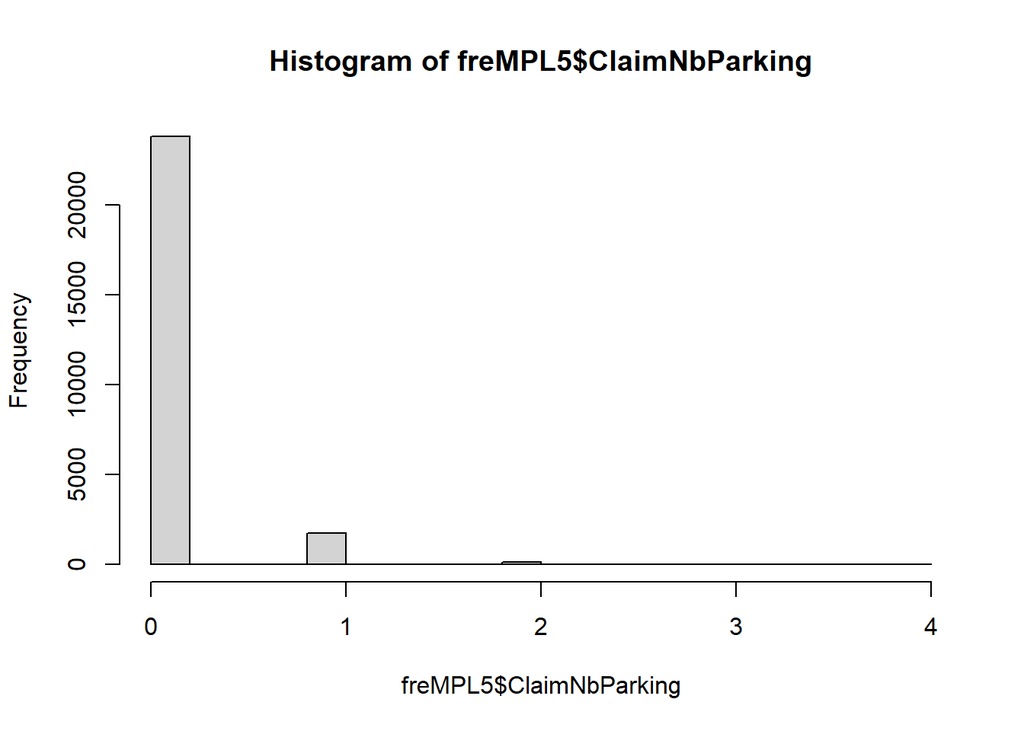

```r
hist(freMPL5$ClaimNbParking)
```

L’évènement d’avoir au moins un accident en se garant est très rare (environ 5%).

##### Etude par rapport à la sinistralité

```r
cor.test(freMPL5$ClaimNbParking, as.numeric(freMPL5$ClaimInd))
```

```
##
##  Pearson's product-moment correlation
##
## data:  freMPL5$ClaimNbParking and as.numeric(freMPL5$ClaimInd)
## t = 3.6552, df = 25720, p-value = 0.0002575
## alternative hypothesis: true correlation is not equal to 0
## 95 percent confidence interval:
##  0.0105679 0.0349968
## sample estimates:
##        cor
## 0.02278575
```

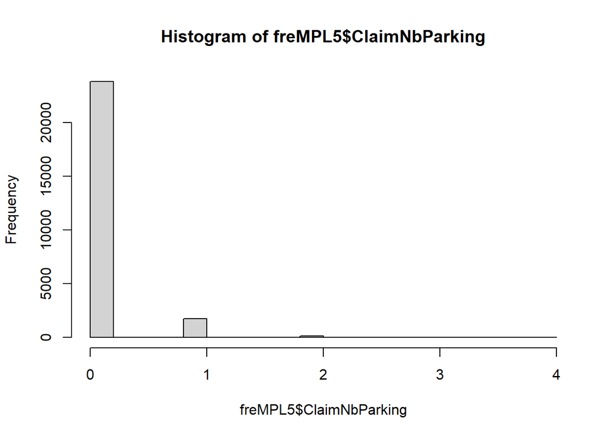

```r
hist(freMPL5$ClaimNbParking)
```

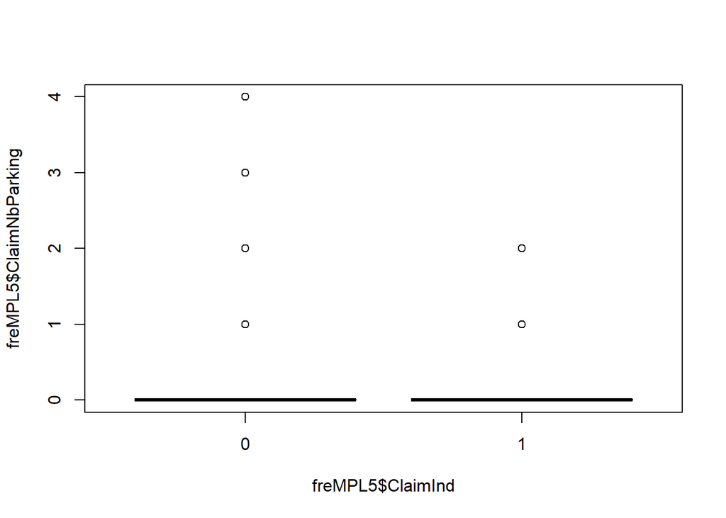

```r
boxplot(freMPL5$ClaimNbParking ~ freMPL5$ClaimInd)
```

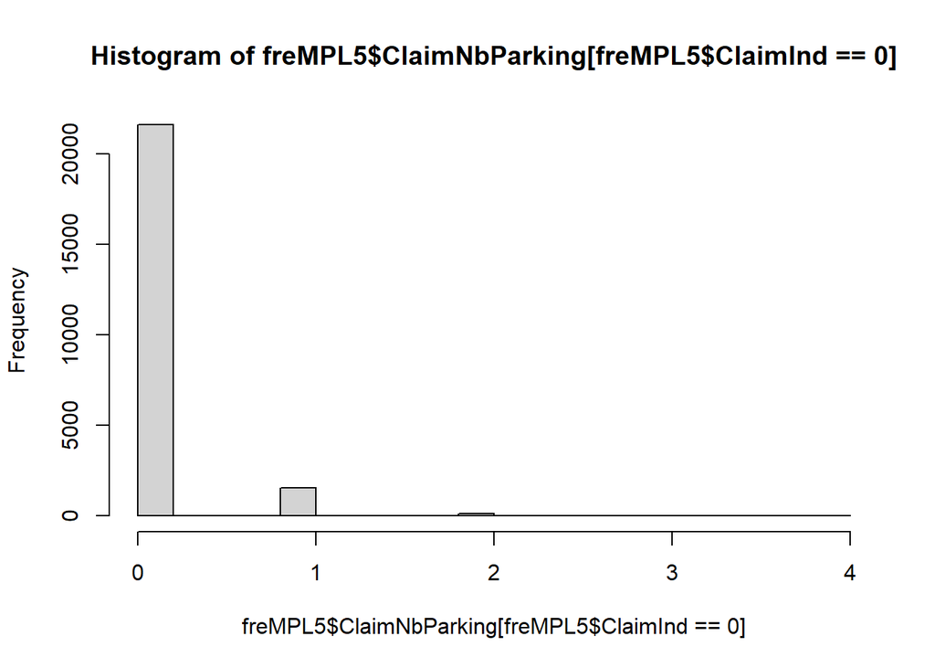

```r
hist(freMPL5$ClaimNbParking[freMPL5$ClaimInd == 0])
```

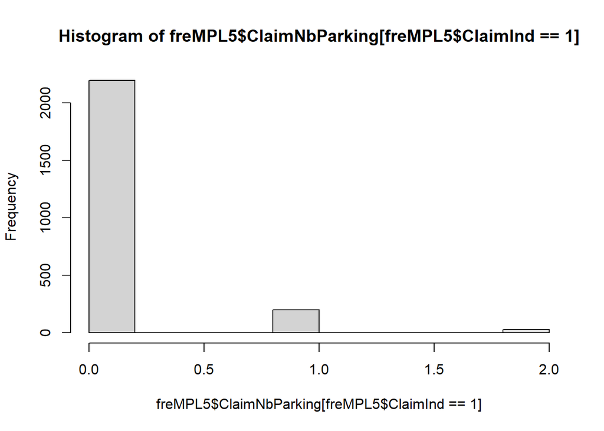

```r
hist(freMPL5$ClaimNbParking[freMPL5$ClaimInd == 1])
```

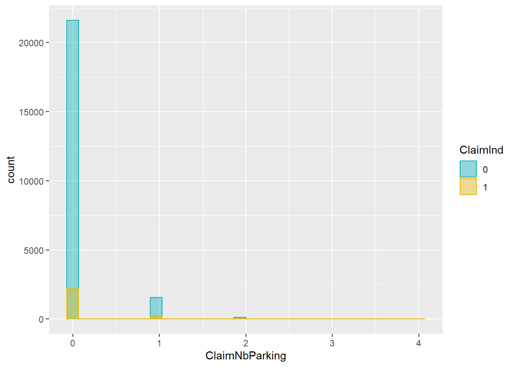

```r
ggplot(freMPL5, aes(x = ClaimNbParking)) +
  geom_histogram(aes(color = ClaimInd, fill = ClaimInd),
                position = "identity", bins = 30, alpha = 0.4) +
  scale_color_manual(values = c("#00AFBB", "#E7B800")) +
  scale_fill_manual(values = c("#00AFBB", "#E7B800"))
```

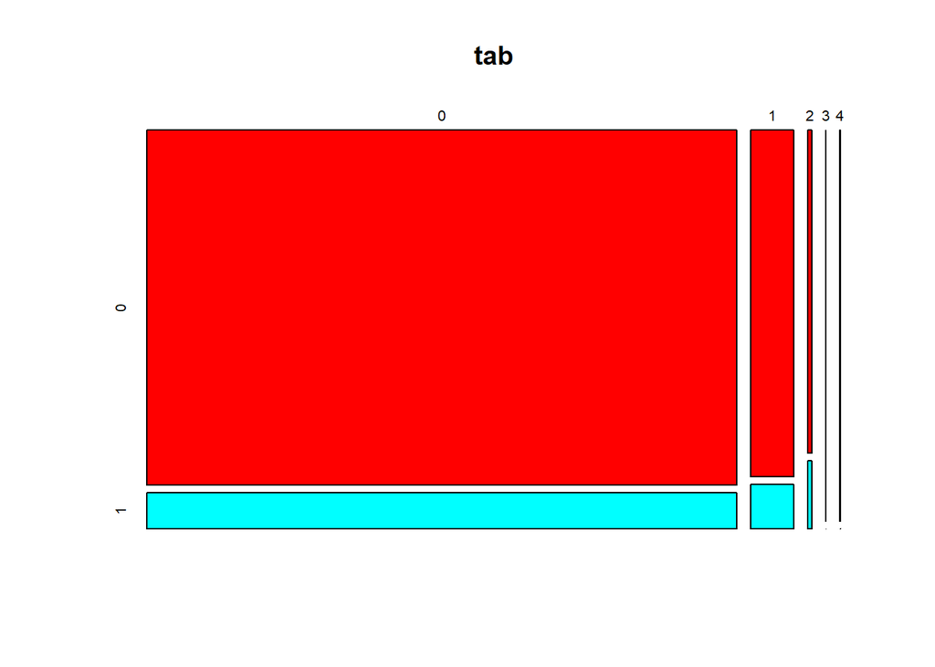

```r
tab <- table(freMPL5$ClaimNbParking, freMPL5$ClaimInd)
cols <- rainbow(nlevels(freMPL5$ClaimInd))
plot(tab,col = cols)
```

Il y a ici aussi une petite corrélation. Avec les graphiques, on remarque qu’il y a plus d’indicateurs de réclamation positifs lors d’accidents en stationnement.

##### Etude par rapport au coût

```r
cor.test(freMPL5$ClaimNbParking, freMPL5$ClaimAmount)
```

```
##
##  Pearson's product-moment correlation
##
## data:  freMPL5$ClaimNbParking and freMPL5$ClaimAmount
## t = 1.0134, df = 25720, p-value = 0.3109
## alternative hypothesis: true correlation is not equal to 0
## 95 percent confidence interval:
##  -0.005902342  0.018538270
## sample estimates:
##         cor
## 0.006318908
```

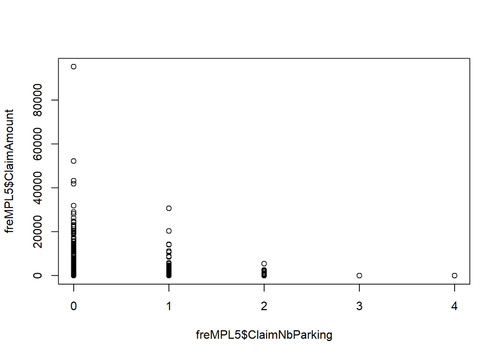

```r
plot(freMPL5$ClaimAmount ~ freMPL5$ClaimNbParking)
```

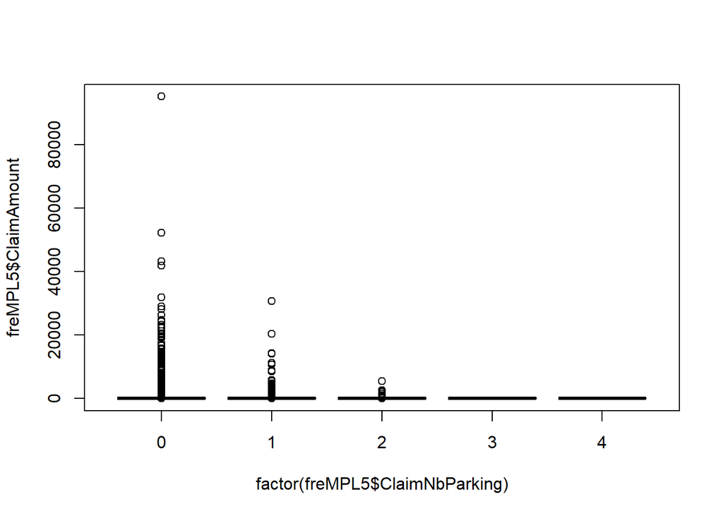

```r
boxplot(freMPL5$ClaimAmount ~ factor(freMPL5$ClaimNbParking))
```

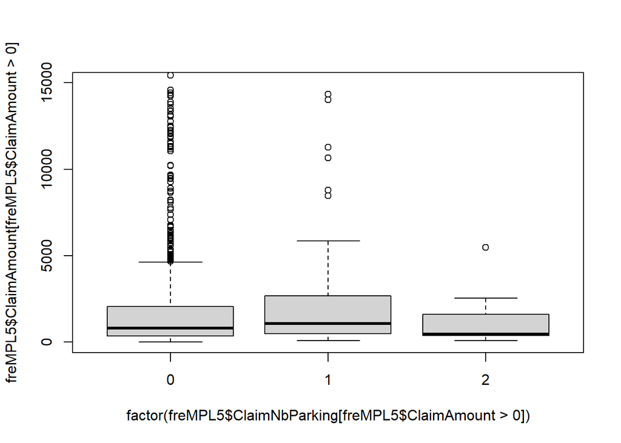

```r
boxplot(freMPL5$ClaimAmount[freMPL5$ClaimAmount>0] ~ factor(freMPL5$ClaimNbParking[freMPL5$ClaimAmount>0]), ylim=c(0,15000))
```

### Incendie ou vol

```r
summary(freMPL5$ClaimNbFireTheft)
```

```
##    Min. 1st Qu.  Median    Mean 3rd Qu.    Max.
## 0.00000 0.00000 0.00000 0.07639 0.00000 3.00000
```

```r
quantile(freMPL5$ClaimNbFireTheft, seq(0,1,1/20))
```

```
##   0%   5%  10%  15%  20%  25%  30%  35%  40%  45%  50%  55%  60%  65%  70%  75%
##    0    0    0    0    0    0    0    0    0    0    0    0    0    0    0    0
##  80%  85%  90%  95% 100%
##    0    0    0    1    3
```

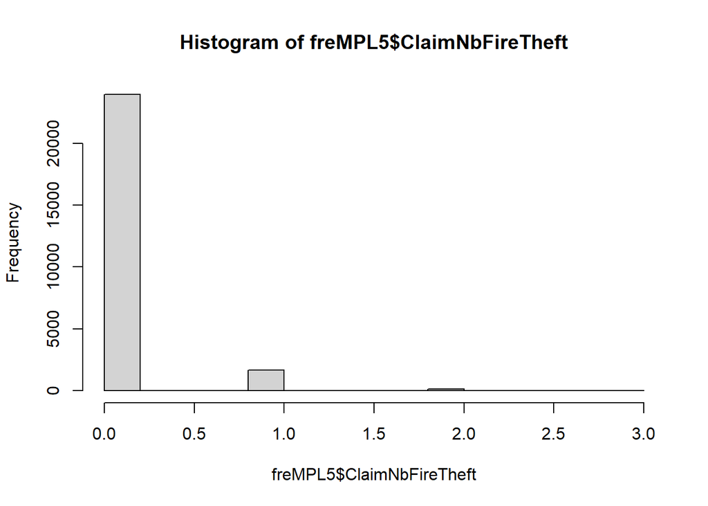

```r
hist(freMPL5$ClaimNbFireTheft)
```

L’évènement d’avoir un vol ou incendie de la voiture est très rare (environ 5%).

##### Etude par rapport à la sinistralité

```r
cor.test(freMPL5$ClaimNbFireTheft, as.numeric(freMPL5$ClaimInd))
```

```
##
##  Pearson's product-moment correlation
##
## data:  freMPL5$ClaimNbFireTheft and as.numeric(freMPL5$ClaimInd)
## t = 3.398, df = 25720, p-value = 0.00068
## alternative hypothesis: true correlation is not equal to 0
## 95 percent confidence interval:
##  0.00896437 0.03339499
## sample estimates:
##        cor
## 0.02118284
```

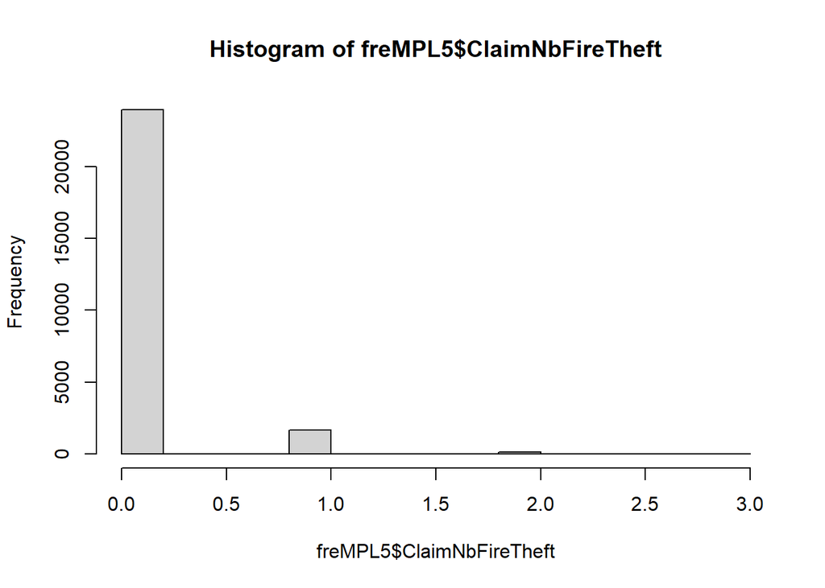

```r
hist(freMPL5$ClaimNbFireTheft)
```

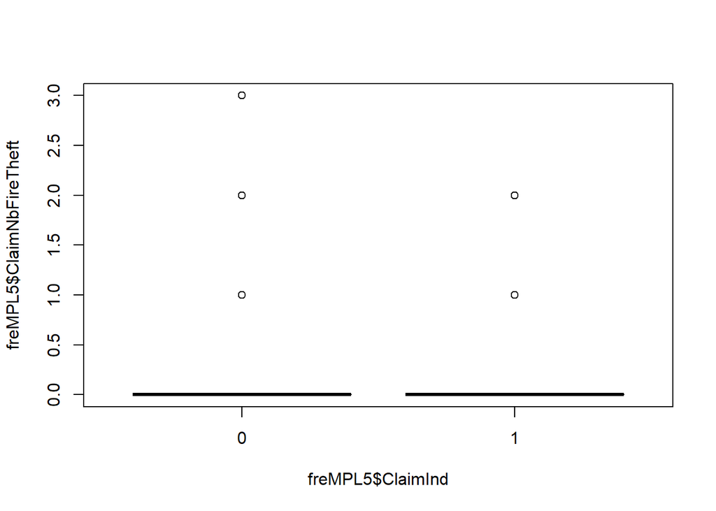

```r
boxplot(freMPL5$ClaimNbFireTheft ~ freMPL5$ClaimInd)
```

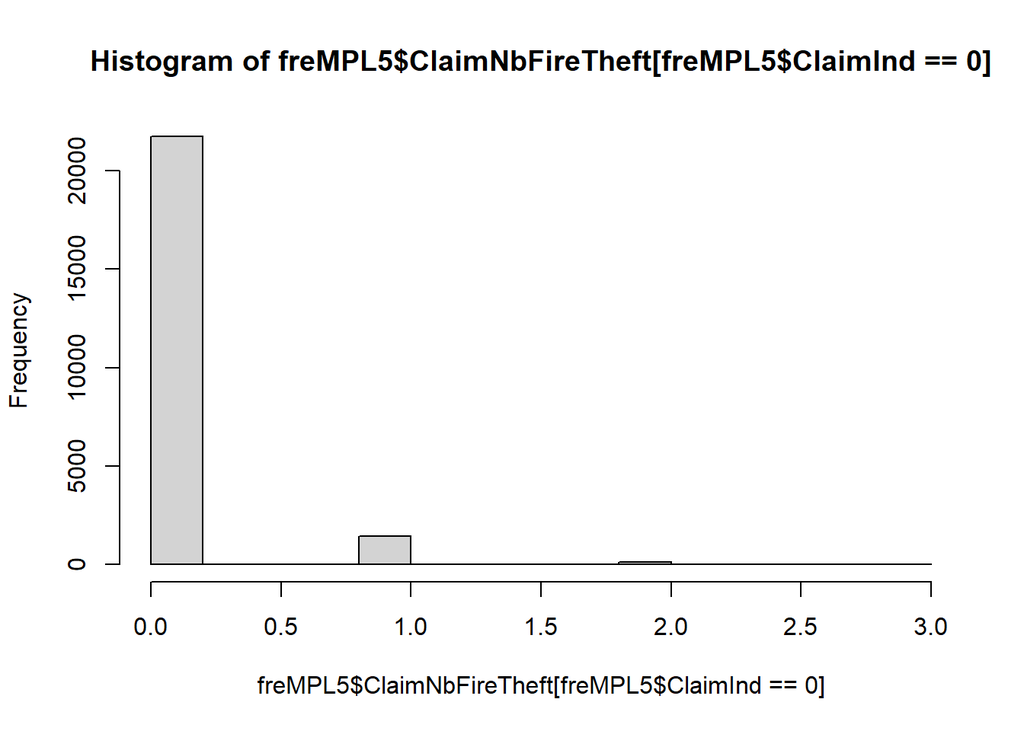

```r
hist(freMPL5$ClaimNbFireTheft[freMPL5$ClaimInd == 0])
```

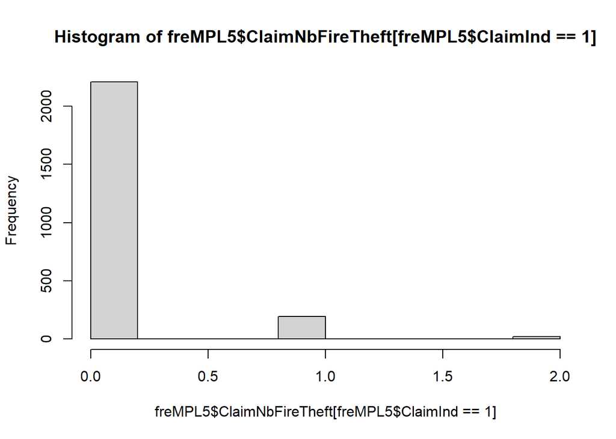

```r
hist(freMPL5$ClaimNbFireTheft[freMPL5$ClaimInd == 1])
```

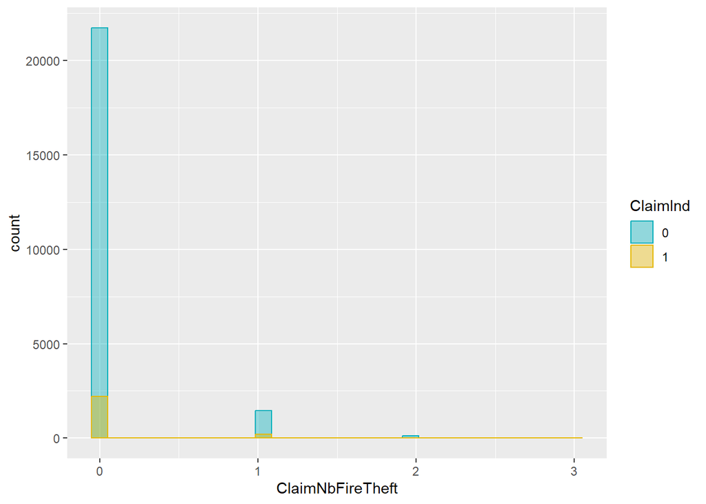

```r
ggplot(freMPL5, aes(x = ClaimNbFireTheft)) +
  geom_histogram(aes(color = ClaimInd, fill = ClaimInd),
                position = "identity", bins = 30, alpha = 0.4) +
  scale_color_manual(values = c("#00AFBB", "#E7B800")) +
  scale_fill_manual(values = c("#00AFBB", "#E7B800"))
```

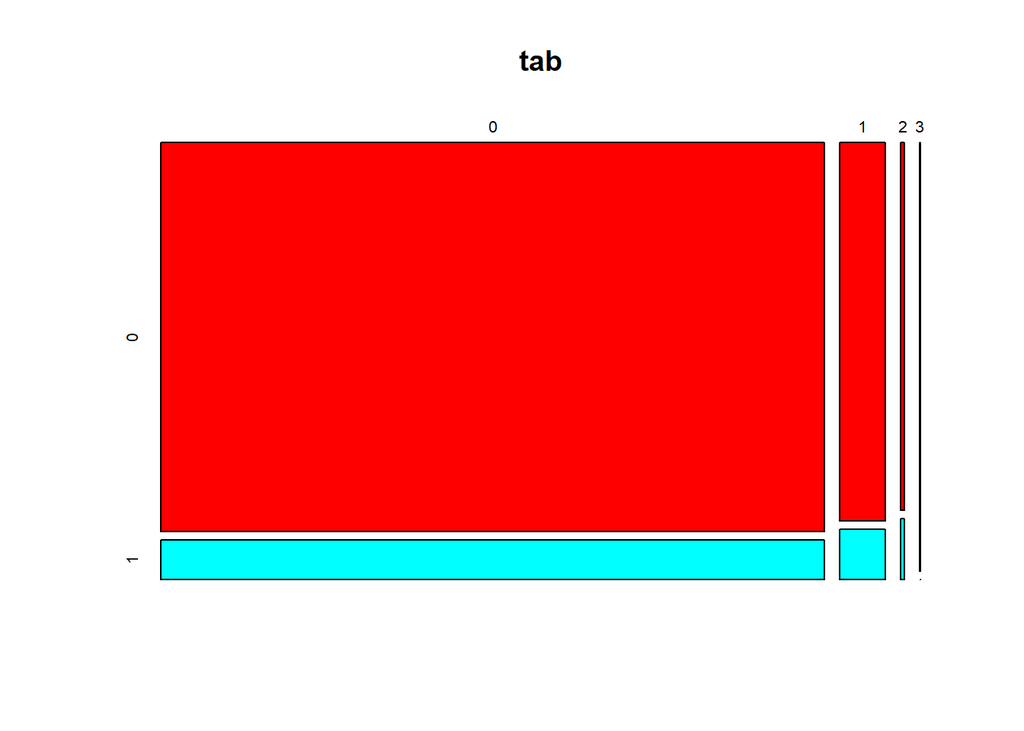

```r
tab <- table(freMPL5$ClaimNbFireTheft, freMPL5$ClaimInd)
cols <- rainbow(nlevels(freMPL5$ClaimInd))
plot(tab,col = cols)
```

Il y a ici aussi une petite corrélation. Avec les graphiques, on remarque qu’il y a plus d’indicateurs de réclamation positifs lorsqu’il y a eu vol ou incendie.

##### Etude par rapport au coût

```r
cor.test(freMPL5$ClaimNbFireTheft, freMPL5$ClaimAmount)
```

```
##
##  Pearson's product-moment correlation
##
## data:  freMPL5$ClaimNbFireTheft and freMPL5$ClaimAmount
## t = 2.0501, df = 25720, p-value = 0.04037
## alternative hypothesis: true correlation is not equal to 0
## 95 percent confidence interval:
##  0.0005612815 0.0249988772
## sample estimates:
##        cor
## 0.01278199
```

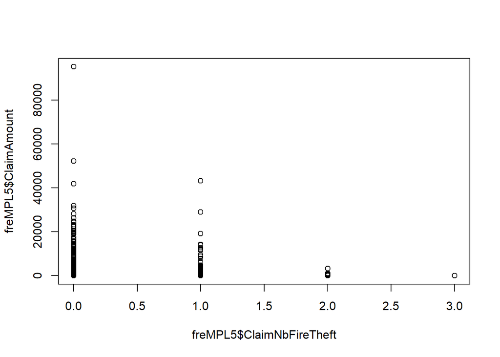

```r
plot(freMPL5$ClaimAmount ~ freMPL5$ClaimNbFireTheft)
```

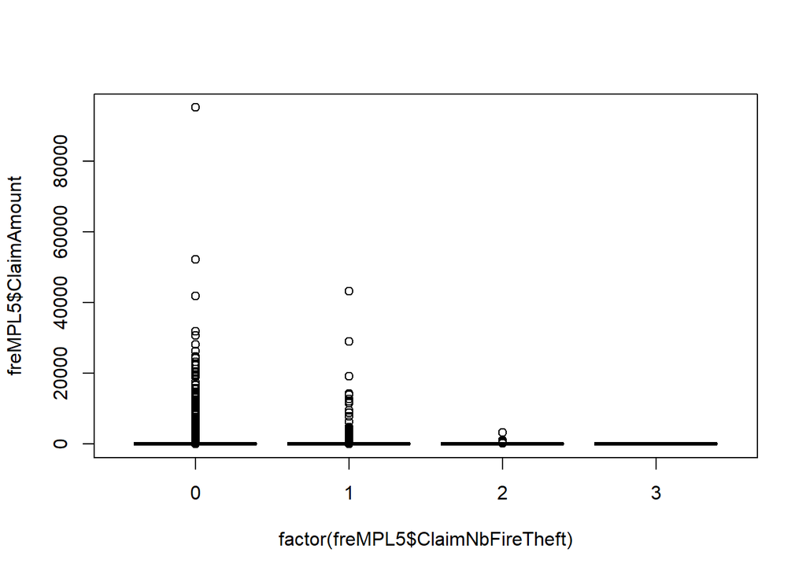

```r
boxplot(freMPL5$ClaimAmount ~ factor(freMPL5$ClaimNbFireTheft))
```

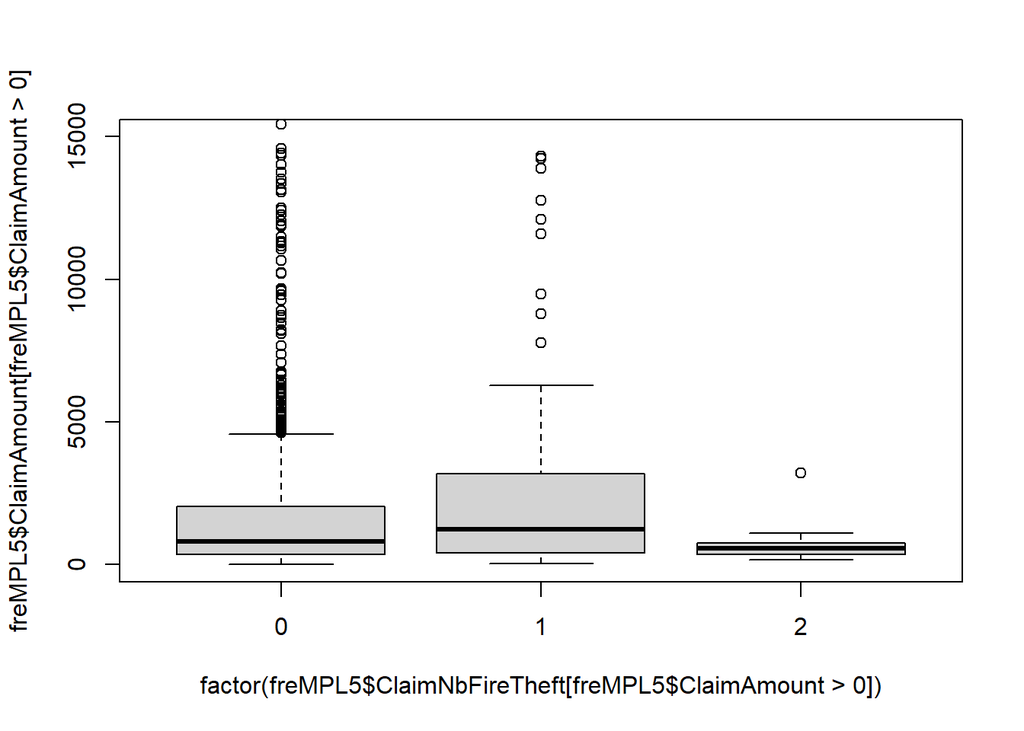

```r
boxplot(freMPL5$ClaimAmount[freMPL5$ClaimAmount>0] ~ factor(freMPL5$ClaimNbFireTheft[freMPL5$ClaimAmount>0]), ylim=c(0,15000))
```